# Racket 中的 DSL：现在，你想怎样实现？DSLs in Racket: You Want It How, Now?

**Yunjeong Lee**

新加坡国立大学 · 新加坡National University of Singapore · Singapore

yunjeong.lee@u.nus.edu

**Kiran Gopinathan**

新加坡国立大学 · 新加坡National University of Singapore · Singapore

mail@kirancodes.me

**Ziyi Yang**

新加坡国立大学 · 新加坡National University of Singapore · Singapore

yangziyi@u.nus.edu

**Matthew Flatt**

犹他大学 · 美国University of Utah · USA

mflatt@cs.utah.edu

**Ilya Sergey**

新加坡国立大学 · 新加坡National University of Singapore · Singapore

ilya@nus.edu.sg

[SLE ’24 · DOI: 10.1145/3687997.3695645](https://doi.org/10.1145/3687997.3695645) · PDF

## 摘要Abstract

领域特定语言（DSL）是一种广受欢迎的方式，可简化并精炼针对常见但专业化任务的编程解决方案。虽然用于实现领域特定语言的框架设计一直是研究界的热门课题，但对于实践者最终如何使用这些框架，以及框架的各项特性对于构建实际应用中的领域特定语言有多大价值，相关研究却少得多。Domain-Specific Languages (DSLs) are a popular way to simplify and streamline programmatic solutions of commonly occurring yet specialized tasks. While the design of frameworks for implementing DSLs has been a popular topic of study in the research community, significantly less attention has been given to studying how those frameworks end up being used by practitioners and assessing utility of their features for building DSLs “in the wild”.

本文开展了这样一项研究，重点考察一种用于构建领域特定语言的特定框架：Racket 编程语言。我们提出了（a）一套针对嵌入 Racket 的领域特定语言所能实现的语言设计意图的新分类体系，以及（b）对运用 Racket 机制来实现这些意图的方式的分类。我们通过分析 30 种流行的基于 Racket 的领域特定语言，为这一分类体系提供实证支持，并讨论它们如何利用现有机制来实现各自的设计意图。这套分类体系可作为一种可复用的衡量标准，帮助语言设计者在 Racket 及其他框架中系统地开发、比较和分析领域特定语言。In this paper, we conduct such a study focusing on a particular framework for DSL construction: the Racket programming language. We provide (a) a novel taxonomy of language design intents enabled by Racket-embedded DSLs, and (b) a classification of ways to utilize Racket’s mechanisms that make the implementation of those intents possible. We substantiate our taxonomy with an analysis of 30 popular Racket-based DSLs, discussing how they make use of the available mechanisms and accordingly achieve their design intents. The taxonomy serves as a reusable measure that can help language designers to systematically develop, compare, and analyze DSLs in Racket as well as other frameworks.

CCS 概念：• 软件及其工程 → 领域特定语言。CCS Concepts: • Software and its engineering →Domain specific languages.

关键词：领域特定语言，元编程Keywords: domain-specific languages, meta-programming

ACM 参考文献格式：Yunjeong Lee、Kiran Gopinathan、Ziyi Yang、Matthew Flatt 和 Ilya Sergey。2024 年。《Racket 中的领域特定语言：你现在到底想要怎样的语言？》（DSLs in Racket: You Want It How, Now?）。载于第 17 届 ACM SIGPLAN 软件语言工程国际会议论文集（SLE ’24），2024 年 10 月 20–21 日，美国加利福尼亚州帕萨迪纳。ACM，美国纽约州纽约市，20 页。https://doi.org/10.1145/3687997.3695645ACM Reference Format: Yunjeong Lee, Kiran Gopinathan, Ziyi Yang, Matthew Flatt, and Ilya Sergey. 2024. DSLs in Racket: You Want It How, Now?. In Proceedings of the 17th ACM SIGPLAN International Conference on Software Language Engineering (SLE ’24), October 20–21, 2024, Pasadena, CA, USA. ACM, New York, NY, USA, 20 pages. https://doi.org/10.1145/3687997.3695645

本作品采用知识共享署名—相同方式共享 4.0 国际许可协议授权。This work is licensed under a Creative Commons Attribution-ShareAlike 4.0 International License.

SLE ’24，2024 年 10 月 20–21 日，美国加利福尼亚州帕萨迪纳。© 2024 版权由所有者／作者持有。ACM ISBN 979-8-4007-1180-0/24/10 https://doi.org/10.1145/3687997.3695645SLE ’24, October 20–21, 2024, Pasadena, CA, USA © 2024 Copyright held by the owner/author(s). ACM ISBN 979-8-4007-1180-0/24/10 https://doi.org/10.1145/3687997.3695645

## 1 引言1 Introduction

开发软件时，程序员往往希望使用针对当前问题量身定制的领域特定语言（DSL）：例如，用“regex”语言表示正则表达式，用类似 `make` 的领域特定语言表示构建依赖关系，或用 `SQL` 语言进行关系查询。遗憾的是，从零构建这样的领域特定语言并非易事，因为开发者既要编写包含语法分析器、词法分析器等组件的前端，还要为语言本身提供适用的库和定义。这些困难可能使开发者放弃创建和使用领域特定语言。Racket 编程语言 [12] 致力于解决这一难题，旨在推广并简化领域特定语言的开发。Racket 鼓励用户将自己的领域特定语言嵌入 Racket 本身，并提供大量特性来简化这一过程。其中最突出的是，它支持可定制的语法分析器，以及基于宏的元编程功能，以定义领域特定语言的语法；同时，它还提供模块系统，以便在不同的嵌入式语言之间复用库。这些功能共同构成了一个面向语言编程的框架。When developing software, programmers often want domain-specific languages (DSLs) that are tailored for the problem at hand: such as using “regex” languages to express regular expressions, `make`-like DSLs for expressing build dependencies, or `SQL` languages for relational queries. Unfortunately, constructing such DSLs from scratch can be a challenge, because it requires the developer to write a front-end with a parser, lexer, etc., as well as suitable libraries and definitions for use within the language itself. These challenges can dissuade a developer from creating and using a DSL. The Racket programming language [12] addresses this challenge and aims to popularize and streamline the development of DSLs. Racket encourages its users to embed their DSLs within the language itself, and it supports a litany of features to simplify this process. Most prominently, it supports customizable parsers and macro-based metaprogramming support to define a DSL’s syntax, and it provides a module system for reusing libraries between different embedded languages. Together, these facilities provide a framework for language-oriented programming.

过去十年间，Racket 语言及其生态系统日趋成熟、蓬勃发展，这既得益于研究者对语言的扩展，也得益于开发者利用这些特性构建新的领域特定语言。研究方面的工作通过新技术和新功能扩展 Racket，以支持领域特定语言的构建：例如，支持宏调试 [9]，提供用于编写具备健壮错误处理能力的宏的工具 [10]，或确保以卫生的方式处理作用域和变量 [15]；近期还有一个框架，用于构建基于宏且可由最终用户扩展的领域特定语言 [3]。与此同时，Racket 生态系统不断迎来新用户和开发者，他们采用面向语言的编程范式，并在 Racket 中构建自己的领域特定语言。例如，截至撰稿时，Racket Package Index 已收录多达 2106 个包 [32]，为其他用户提供库和领域特定语言。The past decade has seen both the Racket language and ecosystem mature and flourish, with contributions both from researchers extending the language and from developers using these features to build new DSLs. The research side includes work that extends Racket with new techniques and facilities to support DSL construction: support for debugging macros [9], tooling for writing macros with robust error handling [10] or ensuring hygienic treatment of scope and variables [15], and recently a framework for constructing macro-based DSLs that are also extensible by end users [3]. At the same time, the Racket ecosystem has seen a steady flow of new users and developers adopting the language-oriented paradigm and building their own DSLs in Racket. For example, at the time of writing, the Racket Package Index lists a substantial number of 2106 packages [32], providing libraries and DSLs for others to use.

鉴于这一生态系统的现状，如今可以就其使用情况提出一些值得探讨的问题。最重要的是，Racket 为语言设计提供的各种宏编程功能，是否确实在实际应用中得到了使用？如果确实如此，Given the state of the ecosystem, it is possible to now pose interesting questions about its use. Most importantly, are the various macro-programming facilities that Racket provides for language design actually used “in the wild”? And if so,

那么，语言设计者自身的哪些具体意图，得到了 Racket 功能的有效支持？这些问题的答案此前一直未知；据我们所知，以往尚无研究考察过 Racket 各种机制在整个生态系统中的实际使用情况，或语言设计者在实践中如何利用它们实现自己的领域特定语言。what specific intents of the language designers themselves are effectively supported by Racket facilities? The answers to these questions have previously been unknown; to the best of our knowledge, no prior work has conducted any study of the real-world use of Racket mechanisms across its ecosystem or how they are employed in practice by language designers to implement their DSLs.

本文通过研究 Racket 在领域特定语言设计中的实际应用来回答这些问题。我们从语言设计者的角度呈现研究结果，并考察实践中如何利用 Racket 的各种特性来实现语言设计目标。本工作的主要贡献如下：In this paper, we answer these questions by performing a study of the real-world uses of Racket for designing DSLs, presenting our findings from the perspective of a language designer and investigating how the various features of Racket are employed in practice to facilitate the goals of language design. The main contributions of this work are as follows:

- 我们识别了一组语言设计意图，即语言设计者对于其语言的外观和使用体验所抱有的隐含目标，并基于对 Racket 生态系统的研究提出了一套系统的分类体系（第 3 节）。We identify a family of language design intents—implicit goals that a language designer has in mind with regard to how their language will look and feel—and present a systematic taxonomy based on a study of the Racket ecosystem (Sec. 3).
- 对于每一种设计意图，我们研究并分类说明如何能够、以及实践中如何已经运用 Racket 的各种特性来实现它们（第 4 节）。我们给出了利用这些机制实现各项设计意图的领域特定语言实现示例。For each of these design intents, we investigate and clas-sify how the various features of Racket can be and are employed to achieve them (Sec. 4). We provide example implementations of DSLs using those mechanisms to achieve each design intent.
- 最后，我们使用这一分类体系，从设计意图和实现机制两个方面，对 Racket 生态系统中 30 种流行的领域特定语言进行了全面分析。此外，我们还为 Racket 开发者、用户以及编程语言研究界提出了若干未来工作的建议（第 5 节）。Finally, using this classification system, we provide an extensive analysis of the 30 popular DSLs from the Racket ecosystem in terms of design intents and mechanisms. We also present a number of suggestions for future work for the Racket developers, its users, and the programming language research community (Sec. 5).

## 2 Racket 领域特定语言：用户视角2 A Racket DSL: the User’s Perspective

Racket 自称是一种用于编写编程语言的编程语言 [12]，其生态系统旨在提供一个创建领域特定语言的元编程框架。在领域特定语言设计这一背景下，Racket 与其他语言的不同之处在于，它使用户——也就是领域特定语言的作者——能够轻松地改变和定制自己语言的外观及使用体验。具体而言，Racket 既允许领域特定语言作者采用任意语法，也允许他们借助 Racket 本身，利用 Racket 的元编程功能为程序定义自定义语义。将领域特定语言嵌入 Racket 而非从零编写的做法，使语言作者既能利用 Racket 自身丰富的生态系统，又能全面定制领域特定语言代码的处理和运行方式，而无需从头实现一门完整的语言。本节将从最终用户的视角，以编写一个简单游戏作为贯穿示例，逐步介绍 Racket 的元编程能力，以说明 Racket 的领域特定语言设计方法中的主要组成部分。Self-styled as a programming-language programming language [12], the Racket ecosystem seeks to provide a meta-programming framework for creating DSLs. In the context of designing DSLs, what differentiates Racket from other languages is in its ability to empower its users—i.e., DSL authors—to easily change and customize the look and feel of their DSLs. In particular, Racket allows DSL authors to both adopt an arbitrary syntax for their DSL and to piggy-back on top of Racket, allowing them to use Racket’s metaprogramming facilities to define custom semantics for their programs. This approach of embedding DSLs into Racket, rather than writing them from scratch, enables language authors to take advantage of Racket’s own rich ecosystem while also being able to fully customize the way the DSL code is processed and run, all without implementing a full-fledged language from scratch. In this section, to illustrate the main components of Racket’s approach to DSL design, we will provide a step-by-step walk-through of Racket’s meta-programming capabilities from the perspective of an end user, programming a simple game as a running example.

### 2.1 Racket 入门2.1 A Racket Primer

考虑在 Racket 中开发一款“Clickomania”游戏的任务。Clickomania 是一款单人逻辑游戏，其棋盘上布满颜色或图像各异的方块，如图 1 所示。每一回合，玩家可以移除某个方块周围与之相邻、且颜色或图像相同的所有方块。玩家的目标是尽可能多地清除棋盘上的方块。为了实现这款游戏，开发者需要编写函数，表达游戏在逻辑和图形方面的各种行为。这些操作包括：随机选择图像，根据窗口或方块大小调整图像尺寸，设置背景图像，移除相邻且图像或颜色相同的方块，在移除方块时计算得分，为空方块填入图像，运行游戏本身，等等。由于这些调整数量众多且较为复杂，将这些例程封装为少数几个带有多个参数的函数会既不方便又繁琐。相比之下，可定制的 Clickomania 更适合通过专用的领域特定语言来实现。Consider the task of developing a “Clickomania” game in Racket. Clickomania is a oneplayer, logical game where a board is populated with blocks of different colors or images, as shown in Fig. 1. At each turn, the player is allowed to remove all adjacent blocks of the same color or image around a given block. In this game, the player’s goal is to clear as many blocks as possible from the board. To implement the game, the developer will need to develop functions that encode its various logical and graphical aspects. These include operations such as choosing random images, resizing images based on the frame or the block size, setting background images, removing blocks when they are adjacent and are of the same image or color, calculating scores upon removal, populating images in the empty blocks, running the game itself, and many more. Due to the number and complexity of these adjustments, it would be inconvenient and tedious to package these routines into a small number of functions with multiple parameters. Instead, a customizable Clickomania would be far more suited as a candidate for a dedicated DSL.

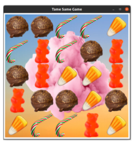

图 1. Clickomania 游戏画面Fig. 1. Clickomania screen

首先，考虑 Clickomania 实现中的两个具体函数。第一个函数表达游戏自身的内部行为，第二个函数则定制用于绘制用户界面的图像。图 2 展示了这两个函数在原生 Racket 中的实现。我们首先定义记录类型 `wstate` 来表示游戏状态，其中的字段包括鼠标点击的 (𝑥,𝑦) 坐标、用于累计鼠标点击次数的计数器、表示一组未消除方块的图像、未消除方块的剩余数量，以及累计得分（第 3 行）。我们还创建了全局变量 `curr-idxs`，它是一个由索引构成的可变矩阵——即列表的列表——用于跟踪方块状态。根据颜色数量和方块总数，矩阵被填入随机选取的索引（第 5–7 行）。为表达移除相同图像的行为——这些图像由各自的索引编号表示——`negate-same-indexes-around` 函数首先收集 `lst` 中相邻图像的索引（第 10–13 行），然后递归遍历相邻方块，收集所有需要取负的方块的列索引和行索引（第 15–16 行），最后将所收集方块的全部索引取负（第 19–20 行）。随后，每次收到鼠标点击输入时，都会使用这个函数更新类型为 `wstate` 的当前游戏状态，从而生成新的游戏画面。To begin, consider two particular functions from the Clickomania implementation. The first one encodes the internal behavior of the game itself, while the second one customizes images for rendering the user interface. Fig. 2 shows these functions implemented in vanilla Racket. We first specify a record type `wstate` to represent the game state, containing fields for an (𝑥,𝑦) coordinate of a mouse click, a counter to add up the number of mouse clicks, an image that represents a group of live blocks, a remaining number of live blocks, and an accumulated score (line 3). We also create a global variable `curr-idxs`, which is a mutable matrix—a list of lists—of indexes to keep track of states of blocks. The matrix is populated with randomly chosen indexes based on the number of colors and the total number of blocks (lines 5-7). To encode the behavior of removing same images which are represented with their respective index numbers, the `negate-same-indexes-around` function first collects indexes of images that are adjacent in `lst` (lines 10-13), recursively traverses the adjacent blocks and collect all the column and row indexes of the blocks to negate (lines 15- 16), and negates all the indexes of the collected blocks (lines 19-20). Subsequently, this function is used to update the current game state of type `wstate` upon each mouse click input, thereby populating the new game screen.

为了定制背景和方块所使用的图像，函数 `adjust-image-with-path` 通过To customize images for background as well as the blocks, the function `adjust-image-with-path` resizes images by

```
#lang racket
(require 2htdp/image)
(define-struct wstate [position counter image remaining score])

(define curr-idxs ; (Listof (Listof Number))
  (let ([idxs (choose-rand-idxs num-colors num-blocks)])
    (lst->lstlst idxs edge-size)))

(define (negate-same-indexes-around col-row curr-idx)
  (let* ([lst (if (= -2 curr-idx)
                  (list) ; If empty (-2), return empty list
                  (list (col-row->u col-row) (col-row->d col-row)
                        (col-row->l col-row) (col-row->r col-row)))]
         ; Traverse adjacent blocks and collect col-row's to negate
         [col-rows-to-negate (collect-col-rows-to-negate
                             lst curr-idx (list col-row))]
         [num-negate-blocks (length col-rows-to-negate)])
    ; Negate indexes in curr-idxs based on col-rows-to-negate
    (for ([col-row col-rows-to-negate])
      (set-at col-row -1))
    (* num-negate-blocks block-score)))

(define (adjust-image-with-path target-size img-path)
  (let* ([img (bitmap/file img-path)]
         [img-width (image-width img)]
         [img-height (image-height img)])
    ; Return an image whose width and height are equal to targe-size
    (scale/xy (/ target-size img-width)
              (/ target-size img-height) img)))
```

图 2. 原生 Racket 中的 Clickomania 游戏代码选段Fig. 2. Selected parts of the Clickomania game in vanilla Racket

根据目标长度（`target-size`），调整通过路径（`img-path`）指定的图像的宽度和高度，来改变其尺寸。它返回调整尺寸后的图像，如图 2 第 23–29 行所示。请注意，除了用于表达上述其他逻辑的函数（例如随机选择图像、为空方块填入图像等）之外，任何 Clickomania 游戏都需要 `negate-same-indexes-around` 和 `adjust-image-with-path` 这两个函数。但这并不意味着每个想要创建这款游戏的人，都必须从零实现所有函数。相反，可以直接调用 `negate-same-indexes-around` 来构建游戏，也可以通过函数 `run` 来构建，后者整合了运行一个游戏实例所需的全部逻辑。adjusting the width and height of an image, provided with its path (`img-path`), based on a target length (`target-size`). It returns a resized image, as shown at lines 23-29 in Fig. 2. Notice that the functions `negate-same-indexes-around` and `adjust-image-with-path` are needed in any Clickomania game, in addition to other functions for encoding the abovementioned logics (e.g., choosing random images, populating images in the empty blocks, etc). This does not mean, however, that anyone who wants to create the game needs to implement all of them from scratch. Instead, one can build games by accessing `negate-same-indexes-around` directly or via a function `run` that incorporates all of the logic needed for running a game’s instance.

### 2.2 用领域特定语言消除样板代码2.2 Removing Boilerplate with a DSL

让我们看看，使用专用的 `clickomania` 领域特定语言创建同一款游戏，会有什么不同。完整代码如图 3 所示。名为 `set-background-image` 的函数设置背景图像，`run` 则执行前述全部内部行为并启动游戏。这两个函数与第 2.1 节中的 `adjust-image-with-path` 可以一起封装为领域特定语言的绑定（即用户可访问的标识符），用户由此能够创建游戏，将选定的图像调整尺寸后设为背景。调整Let us see how creating the same game would differ using a dedicated `clickomania` DSL. The entire code is shown in Fig. 3. A function called `set-background-image` sets the background image, and `run` performs all the internal behaviors mentioned above, starting the game. Given these two functions and `adjust-image-with-path` from Sec. 2.1, they can be packaged together as the DSL bindings (i.e., user-accessible identifiers) that one can use to create a game with a selected image resized and set as a background. Adjusting

图像以适配窗口大小并将其设为背景，只需使用 `adjust-image-with-path` 和 `set-background-image` 即可完成，如图 3 第 3–4 行所示。虽然 `Clickomania` 领域特定语言所面向的问题领域可以说相对简单，但对于更复杂的领域及其操作，抽象的好处就更为明显。例如，Verilog [36] 是一种面向数字系统设计的领域特定语言，用户能够用它轻松描述复杂的电子电路，以进行验证和测试。an image based on the frame size and setting it as the back-ground can be simply done using `adjust-image-with-path` and `set-background-image`, as shown at lines 3-4 of Fig. 3. While the design of the `Clickomania` DSL is arguably concerned with a relatively simple problem domain, the benefits of abstraction are more visible for more complex domains and their operations. For example, Verilog [36] is a DSL designed for digial systems, enabling its users to easily describe complex electronic circuits for verification and testing.

### 2.3 添加自定义语法2.3 Adding Custom Syntax

并非每位开发者都习惯 Racket 基于 S 表达式的语法。例如，熟悉类似 C/Java 的语言的开发者可能更喜欢用花括号将语句分组，而在原生 Racket 中，花括号被视为普通括号（尽管通常建议将其用于特定用途 [17]）。在 Racket 中，可以很容易地支持这种特定语法，如图 4 第 4–9 行所示：代码通过旋转一幅图像并将其叠加到另一幅图像之上，创建一幅新图像，然后进行设置并运行一个游戏实例。Not every developer is comfortable with Racket’s syntax based on S-expressions. For instance, those familiar with C/Java-like languages might prefer grouping of statements using curly braces, which are understood as normal parentheses in vanilla Racket (though typically recommended for a specific use [17]). In Racket, this particular syntax can be accommodated easily, as shown in Fig. 4 (lines 4-9), which creates a new image by rotating an image and overlaying it on top of another, following with setting it up and running a game instance.

Racket 的元编程能力使领域特定语言的语法定制成为可能，其中包括 Racket 标准库所提供的语言前端工具。Customizing the DSL syntax in Racket is made possible by its meta-programming capabilities, including language front-end tools that are part of the Racket’s standard libraries.

```
#lang clickomania

(define sunset (adjust-image-with-path 500 "./sunset.png"))
(set-background-image sunset)
(run 500 5 #:theme "candy" #:num-colors 4 #:num-clicks 10)
```

图 3. 使用 `clickomania` 领域特定语言实现的 Clickomania 游戏实例Fig. 3. Clickomania game instance implemented in the `clickomania` DSL

```
#lang clickomania

(define (create-background-image bsize bg-img-path img-path)
  (if (<= 400 bsize) {
       (define back-img (adjust-image-with-path bsize bg-img-path))
       (define img (adjust-image-with-path (* bsize 0.8) img-path))
       (define rotated-img (rotate -5 bimage))
       (underlay back-img rotated-img)
      }
      (adjust-image-with-path bsize bg-img-path)))

(define sunset-cloud (create-background-image 500 "./sunset.png" "./cloud.png"))
(set-background-image sunset-cloud)
(run 500 5 #:theme "candy" #:num-colors 4 #:num-clicks 10)
```

图 4. 使用花括号表示语句块的 `clickomania` 程序。Fig. 4. A `clickomania` program using curly braces for a block of statements.

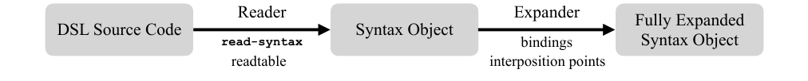

领域特定语言源代码DSL Source Code

语法对象Syntax Object

完全展开的Fully Expanded

语法对象Syntax Object

读取器Reader

展开器Expander

read-syntaxread-syntax

readtablereadtable

绑定bindings

介入点interposition points

图 5. 从领域特定语言源代码到 Racket；箭头下方的组件在第 4 节中介绍。Fig. 5. From DSL source code to Racket; components beneath the arrows are explained in Sec. 4.

我们将在第 4 节详细讨论如何实现图 4 中的语法，以及更多语法形式。现在，先简要了解一下底层处理流程：它将领域特定语言程序转换为 Racket 编译器能够处理的形式，以生成可执行代码，如图 5 所示。We discuss the details of how to enable the syntax of Fig. 4 (and more) in Sec. 4. For now, let us take a brief look at the underlying pipeline of converting a program in DSL into forms that can be processed by Racket’s compiler to produce executable code, as shown in Fig. 5.

Racket 沿用了传统 Lisp 将语法处理划分为读取器和展开器两层的做法 [21]。领域特定语言作者可以扩展或替换读取器，并通过在展开器环境中绑定名称来定制展开器的行为。读取器是专用于某种领域特定语言的语法分析器，它将代码转换为 Racket 基于 S 表达式的表示形式，即语法对象。语法对象是一种数据组件，其中包含源代码片段本身，以及源位置等元数据。在 Racket 中，通过 `#lang` 行从相应模块导入读取器和领域特定语言实现的其余部分。文件中 `#lang` 之后的其余内容都按照读取器的规则进行语法分析。读取器生成语法对象后，该对象会被传递给展开器，后者负责将语法对象改写为编译器能够理解的、类似 Scheme 的核心形式。展开过程依赖于某个项的词法环境中的绑定，而这些绑定由领域特定语言设计者定义和实现。Racket builds on the traditional Lisp split of syntax handling into two layers: the reader and the expander [21]. DSL authors can extend or replace the reader, and they customize the expander’s behavior by binding names in the expander’s environment. A reader is a DSL-specific parser that converts its code into the Racket notation based on S-expressions, known as a syntax objects—data components containing the source code fragment itself, along with its metadata such as source location. In Racket, the reader is imported with the rest of the DSL implementation from the respective module using the `#lang` line. The rest of the file following `#lang` is parsed following its rules. Once the reader generates a syntax object, it gets passed to the expander, responsible for rewriting its syntax object into the Scheme-like core forms that are understood by the compiler. The expansion process relies on bindings in the lexical environment of a term as defined and implemented by a DSL designer.

回到前面图 4 中的 `clickomania` 代码，对花括号的支持是通过定制读取器实现的。与此同时，定制展开器环境则需要定义宏，即将一个语法对象转换为另一个语法对象的编译时函数。基于这一解释，我们接下来看看，通过嵌入领域特定语言，还能实现哪些特定于语言的行为。Going back to the earlier `clickomania` code in Fig. 4, support for curly braces is achieved using the reader customization. At the same time, customizing the expander environment is a matter of defining macros, i.e., compile-time functions that transform one syntax object to another. In the light of this explanation, we now look at what other language-specific behaviors that we can achieve via DSL embedding.

### 2.4 定制语言特有的行为2.4 Tailoring Language-Specific Behavior

利用 Racket 的元编程特性，我们可以通过导入和导出的绑定来定制领域特定语言程序的行为，使原生 Racket 代码与领域特定语言构造能够交互。作为这项特性的第一个示例，我们可以要求任何 `clickomania` 程序都导出 `game-info` 的定义，如图 6 所示，以供客户端应用使用。如果在定义游戏实例时没有提供 `game-info` 的绑定，`clickomania` 程序就会编译失败，并报错提示缺少 `game-info`。这一导出约束是通过 `clickomania` 的展开器环境实现的（参见第 4.3 节），具体做法是定义一个宏，控制整个模块体的使用方式。具体而言，这个宏调整Using the meta-programming features of Racket, we can cus-tomize the behavior of DSL programs through imported and exported bindings, allowing an interaction between vanilla Racket code and DSL constructs. As a first example of this feature, we can make any `clickomania` program export a definition of `game-info`, shown in Fig. 6, for using in client applications. A failure to provide a binding for `game-info` when defining a game instance will cause the compilation of the `clickomania` program to break, triggering an error message that `game-info` is missing. This exporting constraint is achieved via `clickomania`’s expander environment (cf. Sec. 4.3) by defining a macro that controls how an overall module body is used. In particular, the macro accommodates

config.rkt

```
#lang clickomania
(provide run
         create-background-image)

(define (game-info)
  (game-title "Tame Same Game")
  (game-author "Racketeer")
  (values (game-title) (game-author)))
```

图 6. 带有 `game-info` 绑定的 `clickomania` 程序Fig. 6. `clickomania` program with a binding for `game-info`

模块体的展开，使其 `provide`（即导出）`game-info` 的定义。因此，当另一个程序导入图 6 中的模块时（图 8 第 2 行），`game-info` 绑定就会自动在导入方程序中可用，图 8 第 4 行对 `game-info` 绑定的使用展示了这一点。the module body’s expansion to `provide` (i.e., export) the `game-info` definition. Accordingly, when the module from Fig. 6 is imported by another program (line 2, Fig. 8), the `game-info` binding becomes automatically available in the importing program, as illustrated by the usage of `game-info` binding at line 4 in Fig. 8.

其次，我们可以在领域特定语言中编写宏，以扩展语言构造的集合、执行静态检查，或同时实现二者。作为简单静态检查的示例，图 7 包含一个名为 `adjust-image-with-path-macro` 的宏，它将输入语法 `stx` 与一个包含两个参数 `size` 和 `path` 的抽象语法树（AST）模式进行匹配，这两个参数应分别属于 `number` 和 `string` 语法类。这些语法类将语法限制为直接出现的数字和字符串字面量。这里，我们使用了 `syntax-parse` [10] 等用于生成宏的项，而不必额外导入包含这些项的库，如图 7 第 6 行所示。当模式匹配成功时，宏借助一个调用函数 `adjust-image-with-path` 的模板来改写该模式，或者说将其展开为该模板；这一函数可以是图 2 第 23–29 行所定义的函数。本例的约束较为简单，但宏可以作为领域特定语言的绑定提供，以便在编译时检查各种静态强制执行的规则，范围从输入的语法良构性一直到完整的类型系统 [6]。Second, we can write macros in the DSL to extend the set of language constructs, perform static checking, or both. As an example of simple static checking, Fig. 7 includes a macro named `adjust-image-with-path-macro`, which matches the input syntax `stx` against an AST pattern involving two arguments `size` and `path` that should respectively belong to the `number` and `string` syntax classes. Those syntax classes constrain the syntax to immediate number and string literals. Here, we use macro-generating terms such as `syntax-parse` [10] without having to import additional libraries that contain the terms, as shown at line 6 in Fig. 7. When the pattern matching succeeds, the macro rewrites, or expands to, the pattern with a template that calls the function `adjust-image-with-path` such as the one defined in Fig. 2 at lines 23-29. The constraint in this example is simple, but macros can be provided as DSL bindings to allow for the compile-time checking of various statically enforced policies, ranging from syntactic well-formedness of inputs to full-blown type systems [6].

我们还可以通过领域特定语言保证另一种行为：允许像在原生 Racket 中一样，在领域特定语言内编写 Racket 代码。在 Clickomania 中，任何不包含花括号 `{}` 的代码，都与原生 Racket 代码受到相同的处理。这种相互配合Another behavior we can enforce via DSL is the ability to write Racket code in the DSL as in vanilla Racket. In Clickomania, any code that does not involve curly brackets `{}` is treated the same as vanilla Racket code. The interplay

在某些语言中更为复杂，我们将在第 3 节的 `rash` 等领域特定语言中看到这一点。类似地，我们也可以将 `clickomania` 设计为完全不允许用户读取或编写 Racket 代码。is more complex in some languages, as we will see in DSLs like `rash` in Sec. 3. We could similarly design `clickomania` in a way that disallows its users from being able to read or write Racket code whatsoever.

除了领域特定语言语法和 Racket 语法能否在静态层面混用之外，领域特定语言和 Racket 还可以在动态层面以不同程度协作。对于 `clickomania`，我们希望这门领域特定语言能够与 Racket 互操作。这意味着，我们可以创建一个在运行时使用 `clickomania` 代码的 Racket 程序。例如，图 8 为某个应用创建了一个交互式图形用户界面，其中用按钮控件来启动图 6 中的 Clickomania 游戏。具体而言，这种交互Separate from whether DSL syntax and Racket syntax can be mixed statically, DSL and Racket can cooperate to different degrees dynamically. In case of `clickomania`, we want the DSL to be interoperable with Racket. That means we can create a Racket program that uses `clickomania` code at runtime, e.g., by creating an interactive GUI for some application in Fig. 8, where a button widget is used to trigger a Clickomania game from Fig. 6. Specifically, this interaction

mac.rkt

```
#lang clickomania
(provide adjust-image-with-path-macro)
; 'game-info' defined somewhere here
(define-syntax (adjust-image-with-path-macro stx)
  (syntax-parse stx
    [(_ size:number path:string)
     #'(adjust-image-with-path size path)]))
```

图 7. 使用 Racket 宏的 `clickomania` 代码Fig. 7. `clickomania` code featuring a Racket macro

client.rkt

```
#lang racket
(require racket/gui/base
         "config.rkt")
(provide author)
(define-values (title author) (game-info))
(define bg-frame
  (new frame%
       [label (format "~a's Window" author)]))

; Generate a game upon clicking a button
(define (on-button-click b e)
  (set-background-image
   (create-background-image 1000
                            "./dirt.png" "./tree.png"))
  (run 1000 10 #:theme "gem"
       #:num-colors 5 #:num-clicks 20))

(new button% [parent bg-frame]
     [label (format "Play ~a!" title)]
     [callback
      (lambda (b e) (on-button-click b e))])
(send bg-frame show #t)
```

图 8. 创建窗口的 Racket 程序，点击其中的按钮会生成一个 Clickomania 游戏Fig. 8. Racket program creating a window where a button click produces a Clickomania game

展示了如何利用调用 `run` 和 `game-info` 所得到的结果，来定义图 8 中代码的运行时行为。demonstrates using the results of calling `run` and `game-info` to define the runtime behavior of the code from Fig. 8.

### 2.5 综合运用2.5 Putting it All Together

本次介绍最后将展示，第 2.2–2.4 节中嵌入 Racket 的领域特定语言的所有面向用户的特性，如何在图 9 的一个 `clickomania` 程序中共同发挥作用。第一，我们使用 `clickomania` 的函数，例如 `set-game-end-image` 或 `run`。第二，我们使用包含花括号的修改后语法，将第 12–22 行的代码组织为一组。第三，领域特定语言强制要求导出 `game-info`。虽然仅从代码片段无法看出这一强制要求，但我们会在第 4.3 节解释其实现方式。第四，由于该领域特定语言允许编写和使用宏，我们在第 11 行使用了图 7 中的宏。第五，使用这个宏时，会利用 Racket 的宏功能，对传入 `adjust-image-with-path` 函数的参数的有效性进行静态检查，见图 7 第 5–8 行。We wrap up this tour by showing how all the user-facing aspects of Racket-embedded DSLs from Sec. 2.2–2.4 work together in a `clickomania` program in Fig. 9. First, we use `clickomania` functions such as `set-game-end-image` or `run`. Second, we use a modified syntax involving curly braces to arrange a group of code at lines 12-22. Third, exportation of `game-info` is enforced by the DSL. Although this enforcement is not apparent through the code snippet alone, we explain how this is enabled in Sec. 4.3. Fourth, we use a macro from Fig. 7 at line 11, as the DSL lets us write and work with macros. Fifth, when using the macro, Racket’s macro facility is used to statically check the validity of input arguments to the `adjust-image-with-path` function at lines 5-8 in Fig. 7.

```
#lang clickomania
(require "client.rkt" "mac.rkt")

(define (game-info)
  (game-title "Same Game Name")
  (game-author author) ; 'author' imported from client.rkt
  (values (game-title) (game-author)))

(define (my-end-image size img-path txt)
  (define bg ; Use a macro from mac.rkt
    (adjust-image-with-path-macro size img-path))
  (if (<= 200 size) { ; Return an image where a lambda is drawn
       (define over-text (text/font txt (* 0.5 size) "white" #f
                                   'modern 'italic 'normal #f))
       (define-values (end mid) (values (- size 20) (/ size 2)))
       (define line-drawn-bg (add-curve bg 20 20 0 1/3 end end 0 1/3 "white"))
       (underlay (add-curve line-drawn-bg mid mid 0 0 20 end 0 0 "white")
        (text/font txt (* 0.1 size) "white" #f
                   'modern 'italic 'normal #f))
      } bg))
(set-game-end-image (my-end-image 200 "./neon-grid.png" "Try again"))
(run 400 4 #:num-colors 3 #:num-refills 3)
```

图 9. 生成带有个性化结束图像的 Clickomania 游戏的 `clickomania` 程序Fig. 9. `clickomania` program generating a Clickomania game with a personalized ending image

第六，由于我们在使用 Racket 标准图像库函数（例如 `text/font`、`add-curve`、`underlay`）的同时，还隐式地使用了 Racket 的语言构造（例如 `define`、`require` 等），因此能够在图 9 的整个程序中读取和编写普通的 Racket 代码。最后，我们还可以在第 7 行导入并使用图 8 中的绑定 `author`，使领域特定语言程序与 Racket 程序交互。Sixth, as we implicity use Racket language constructs (e.g., `define`, `require`, etc.) on top of Racket’s standard image library functions (e.g., `text/font`, `add-curve`, `underlay`), we are able to read and write plain Racket code throughout the program in Fig. 9. Lastly, we can let the DSL program interact with Racket program by importing and using a binding `author` from Fig. 8 at line 7.

本节展示了使用嵌入 Racket 的领域特定语言是怎样一种体验。接下来，我们将把它的设计分解为一系列意图（第 3 节），并展示如何在 Racket 中实现每一种意图（第 4 节）。In this section, we have seen what it’s like to use a DSL embedded in Racket. Let us now dissect its design into a series of intents (Sec. 3) and show how each of the intents can be implemented in Racket (Sec. 4).

## 3 语言设计意图3 Language Design Intents

本节介绍本文的第一项主要贡献：一套通用分类体系，用于归纳我们在 Racket 生态系统实际代码中观察到的主要设计意图。正如上一节的 Clickomania 示例所展示的，语言设计者在设计语言时，心中可能有许多不同的隐含目标。从实用角度看，对这些目标进行精确分类将很有价值。为此，我们识别了七种设计意图，概括了我们观察到的 Racket 生态系统开发者在实践中的主要目标（参见表 1）。这一意图列表是通过人工考察 Racket 中流行的领域特定语言得到的。In this section, we present the first main contribution of this paper: a general taxonomy of the main design intents observed in use across real-world code found in the Racket ecosystem. As seen through the Clickomania example in the previous section, a language designer may have any number of different implicit goals and objectives in mind when designing their language. From a pragmatic perspective, it will be useful to precisely categorize these. To this end, we have identified seven design intents that capture the main goals and objectives that we have seen in use by developers in the Racket ecosystem (cf. Tab. 1). We gathered the list of intents through manual inspection of popular DSLs in Racket.

本节余下部分将详细描述每一种意图，并以所选的三种实际领域特定语言之一为例，说明这些意图如何应用于具体情境。这三种语言分别是：（1）`frog/config`，用于为静态博客生成器编写配置文件的语言 [26]；（2）`typed/racket`，一种扩展In the rest of this section, we will describe each of these intents in detail, contextualizing each by reference to how they apply in one of the three selected real-world DSLs: (1) the `frog/config` language for writing configuration files for a static blog generator [26], (2) `typed/racket`, an extension

```
#lang frog/config

(define/contract (init) (-> any)
  (current-title "My Blog"))
(define/contract (enhance-body xs)
  (-> (listof xexpr/c) (listof xexpr/c))
  (~> xs (syntax-highlight #:line-numbers? #t)))
(define/contract (clean) (-> any) (void))
```

图 10. 用于博客生成器的 `frog/config` 代码Fig. 10. `frog/config` code for a blog generator

Racket 语言、为其引入类型的语言 [39]；以及（3）`rash`，一种面向 Racket 的类 shell 领域特定语言 [25]。虽然我们无法期望涵盖推动语言设计的所有可能意图，但我们预计，这套分类体系能够覆盖领域特定语言作者在设计和开发语言时最常见的目标。我们将在第 5 节中基于大量案例研究，对这一推测进行定量评估。to Racket language with types [39], and (3) `rash`, a shell-like DSL for Racket [25]. While we cannot expect to capture all possible intentions that motivate language design, we expect that this taxonomy will encompass the most common objectives DSL authors have in mind when designing and developing their languages—a conjecture we quantitatively evaluate on a large corpus of case studies in Sec. 5.

### 3.1 自定义语法3.1 Custom Syntax

构建领域特定语言最显而易见的动机，当然是拥有自定义语法。Racket 的默认语法源自 Lisp，以大量使用括号的 S 表达式为基础，提供了一整套用于函数、数据类型等的表达式和定义形式。这种语法可能相当冗长，促使一些用户寻找替代方案。我们将看到，所选的三种语言分别体现了这一设计空间中的主要不同选择。The most obvious motivation for constructing a DSL is, of course, to have a custom syntax. Racket’s default syntax is inherited from its Lisp roots and based on heavilyparenthesized S-expressions, providing a suite of expression and definition forms for functions, datatypes, etc., which can be quite verbose and might drive some users to seek alternatives. As we shall see, the three selected languages all embody the main different choices in this design space.

首先，`frog/config` 语言（参见图 10）是一个选择完全不改变默认To begin with, the `frog/config` language (cf. Fig. 10) is an example of a DSL that opts not to change the default

表 1. 语言设计意图的描述Table 1. Description of language design intents

| 设计意图Design Intent | 描述Description |
| --- | --- |
| 自定义语法（§3.1）Custom Syntax (§3.1) | 专门构建的、不同于 Racket 默认语法的语法Custom-built syntax that differs from Racket’s default syntax |
| 自定义语义（§3.2）Custom Semantics (§3.2) | 赋予语言构造的、特定于领域特定语言的含义DSL-specific meanings assigned to the language constructs |
| 导入/导出控制（§3.3）Import/Export Control (§3.3) | 管理与导入和／或导出有关的行为Management of import- and/or export-related behaviors |
| 宏支持（§3.4）Macro Support (§3.4) | 用于编写和使用宏的语言功能Language facility to write and work with macros |
| 语法嵌入能力（§3.5）Syntactic Embeddability (§3.5) | 在语法层面将 Racket 嵌入领域特定语言的能力Ability to syntactically embed Racket into the DSL |
| 互操作性（§3.6）Interoperability (§3.6) | 在运行时与 Racket 代码协同工作的能力Ability to work with Racket code at runtime |
| 静态检查（§3.7）Static Checking (§3.7) | 在编译时分析某些属性Analysis of certain properties at compile time |

语法的领域特定语言，它完整保留了宿主语言所特有的、基于 Lisp 的 S 表达式语法。具体而言，这门语言中的定义、表达式及其他形式的语法完全没有改变，可以像普通 Racket 代码一样原样使用，这符合 `frog/config` 用于编写配置文件的设计目的。syntax at all by fully retaining the host language’s characteristic Lisp-based S-expression syntax. In particular, the syntax for definitions, expressions and other forms are entirely unchanged in this language and can be used verbatim as in normal Racket code, fitting the purpose of `frog/config` designed for writing configuration files.

相比之下，`typed/racket` 语言（参见图 11）是一种略微偏离 Racket 默认语法的领域特定语言，因为它允许程序包含使用“`:`”符号的类型注解形式。具体而言，示例代码片段的第 5 行，在声明函数之前放置了一个形式为 `(: <function-id> <function-type>)` 的类型注解。在语法分析时，这一注解形式被处理并解释为相应函数 `my-print-lst` 的类型，而程序其余部分的语法分析方式则与无类型的 `racket` 相同。这样，`typed/racket` 既保留了与宿主语言的相似性，又通过引入类型所需的新形式扩展了宿主语言。The `typed/racket` (cf. Fig. 11) language, on the other hand, presents a DSL with a slight deviation from the default Racket syntax, because it allows programs to include a type-annotation form using the “`:`” symbol. In particular, line 5 in the example snippet contains a type annotation of the form `(: <function-id> <function-type>)` placed before declaring the function. This annotation form is handled and interpreted as a type for the corresponding function `my-print-lst` at the time of parsing, while the rest of the program is parsed the same as in untyped `racket`. This way, `typed/racket` retains similarity with its host language, while, at the same time, extending the host language with new forms needed for typing.

最后，领域特定语言作者也可以选择彻底偏离 Racket 的默认语法，并在语言中加入不基于 S 表达式的形式，`rash` 就是这样的例子（参见图 12）。事实上，`rash` 在这一设计空间中处于一个较为微妙的位置，因为它的代码实际上混合了 S 表达式（例如第 5 行传给 `ls` 的参数）和非 S 表达式，兼有 Racket 的默认语法与自定义语法。这与 `rash` 的用途一致：它是一种能够与 Racket 代码集成的 shell 语言，对 shell 命令采用非 S 表达式语法，对 Racket 代码则采用 Racket 语法。当然，在 `rash` 中包含 Racket 语法是一项有意为之的设计决策，而非必要条件。此外，在实践中，领域特定语言作者还开发出了语法差异更大、更加独特难懂的语言 [19, 33, 41]。Finally, DSL authors may choose to diverge from Racket’s default syntax altogether and incorporate non-S-expressionbased forms in their DSL, as illustrated by `rash` (cf. Fig. 12). In fact, `rash` happens to be a nuanced point in this design space, as its code is actually a mix of S-expressions, e.g. the argument to `ls` at line 5, and non-S-expressions combining both default Racket syntax as well as a custom one. This mirrors `rash`’s purpose as a shell language that can integrate with Racket code, using the non-S-expression syntax for shell commands and Racket syntax for Racket code. Of course, the inclusion of Racket syntax in `rash` is a deliberate design decision, not a requirement. Moreover, in practice, DSL authors have developed languages with even more divergent and esoteric syntax [19, 33, 41].

### 3.2 自定义语义3.2 Custom Semantics

除了为用户提供更友好的前端外，下一个显而易见的设计目标，是为Beyond providing nicer front-ends for the user, the next obvious design goal is in having a bespoke semantics for

用领域特定语言编写的程序提供专门定制的语义。虽然大多数领域特定语言都有自定义语义，但其中仍存在一些细微区别，下面将通过贯穿示例加以说明。programs written in the DSL. While most DSLs have cus-tomized semantics, there is still some nuance to be found, as shall be shown in the running examples.

考虑图 10 中的 `frog/config` 代码。如果我们在原生 Racket 中编写同一个程序，也就是把第 1 行改为 `#lang racket`，会发生什么？虽然用 `frog/config` 编写的程序大体遵循 Racket 的语义，但这门领域特定语言对 Racket 做了一些细小而微妙的改变，尤其是提供了一些 `racket` 中不存在的额外标识符，例如函数 `current-title` 和 `syntax-highlight`。这样，`frog/config` 领域特定语言中的程序可以在适当之处利用领域专用函数，而在其他地方沿用 Racket 的语义。Consider the `frog/config` code presented in Fig. 10. What would happen if we were to write the same program in vanilla Racket, i.e., change the line 1 to `#lang racket`? Although programs written in `frog/config` mostly follow the semantics of Racket, the DSL introduces some small and subtle changes to Racket, in particular providing access to additional identifiers that are not available in `racket`, such as the functions `current-title` and `syntax-highlight`. In this way, programs in the `frog/config` DSL can leverage domain-specific functions where it makes sense, and otherwise fall back to Racket’s semantics.

图 11 中的 `typed/racket` 程序在这一方面同样偏离得更多：它引入了一套全新的静态语义，用于对程序进行类型检查。具体而言，代码示例包含了一些项，它们在 `racket` 本身中并未绑定到任何值或函数，而是仅用于类型检查，例如 `define-type`、`Pairof`、`String`、`Number` 等。类型检查完成后，与前一个示例类似，`typed/racket` 利用宿主语言的语义来实际运行程序。The `typed/racket` program in Fig. 11 again presents a larger deviation on this front, introducing an entirely new static semantics that is used to type-check the program. In particular, the listing includes terms that are not bound to any value or function in `racket` itself but only available for the purposes of type-checking, such as `define-type`, `Pairof`, `String`, `Number`, etc. Once type-checking is completed, then similarly to the previous example, `typed/racket` leverages the host language’s semantics to actually run the program.

最后，`rash` 领域特定语言在自定义程序语义的设计空间中体现了另一种选择：它进一步偏离 Racket，并尝试复现人们对 shell 脚本语言所预期的行为。这门语言向用户提供了管道运算符 `|`，以及图 12 中的 `ls` 命令等，它们的行为被定义为类似相应的 shell 构造，而非 Racket 函数，例如在管道中传播错误码、从标准输入读取数据，或向标准输出写入数据。最后，与前面的示例一样，`rash` 语言也复用了原生 Racket 的语义，为它允许用户集成到领域特定语言中的原生 Racket 形式赋予含义。Finally, the `rash` DSL exhibits a different choice in the space of customized program semantics, and diverges further and attempts to replicate the behaviors expected of a shell scripting language. The language exposes commands such as the pipe operator `|`, or the `ls` command as shown in Fig. 12 to the user, which are defined to behave like their shell counterparts rather than as Racket functions, such as propagating error codes in a pipeline, consuming from standard input, or producing to standard output. Finally, as with the previous examples, the `rash` language again reuses the vanilla Racket semantics to give meaning to the vanilla Racket forms that it allows users to integrate into the DSL.

这三个示例展示了 Racket 中的领域特定语言如何通过提供针对各自领域定制的绑定，来实现不同程度的自定义语义，同时还可以These three examples demonstrate how DSLs in Racket are able to provide a range of custom semantics by exposing bindings tailored to be specific to their domains, but also can

typed-fun.rkt

```
#lang typed/racket

(define-type StrNum (Pairof String Number))

(: my-print-lst (-> (Listof StrNum) Void))
(define (my-print-lst lst)
  (for ([elem lst])
    (printf (car elem) (cdr elem))))
```

图 11. 在 `typed/racket` 中定义带类型的函数。Fig. 11. Defining a typed function in `typed/racket`.

利用 Racket 本身提供的绑定，按需复用其部分语义。¹leverage the bindings provided by Racket itself to reuse parts of its semantics as needed.1

### 3.3 导入/导出控制3.3 Import/Export Control

离开语法和语义的话题，我们现在转向语言设计中一些更细致的方面，首先是领域特定语言的导入/导出控制。具体而言，为了有效塑造语言的外观和使用体验，设计者往往需要一些机制，来约束并细化用户获准导入或导出领域特定语言代码的方式。这一点尤为重要，因为我们已经看到，由库导入和导出的绑定集合可能显著影响领域特定语言本身的语义，因此可能需要要求用户以特定方式导入或导出某些绑定或其他领域特定语言代码。将导入/导出控制纳入设计目标的领域特定语言就体现了这类行为，例如 `frog/config` 或 `typed-racket`。Shifting away from syntax and semantics, we now move to some more nuanced aspects of language design, starting with the control of imports and exports of a DSL. In particular, in order to effectively shape the look and feel of their languages, designers often need mechanisms to constrain and refine the ways their users are allowed to import or export the DSL code. This is especially the case as we have seen that the set of exposed bindings, as imported and exported by libraries, can heavily impact the semantics of the DSL itself, and so users may be required to import or export certain bindings or other DSL code in a specific manner. This kind of behavior is demonstrated by DSLs with an import/export control as part of their design objectives, as shown in DSLs such as `frog/config` or `typed-racket`.

回到图 10 中的 `frog/config` 代码，为确保用户定义了构建博客所需的全部配置变量，语言本身将这一约束作为导出要求强制执行。省略 `init`、`enhance-body` 和 `clean` 三个定义中的任何一个，都会导致程序编译失败，并报错提示用户必须为缺失的标识符提供一个函数。此外，`frog/config` 语言通过阻止用户访问 Racket 的 `provide` 操作符，禁止用户导出任何其他绑定，因为这些绑定与网站配置无关。因此，从任何用 `frog/config` 编写的程序中能够访问的标识符，都仅限于该配置语言自动导出的这三个。Returning back to our `frog/config` code in Fig. 10, in order to ensure that the user has defined all the necessary configuration variables to build the blog, the language itself enforces this constraint as an export requirement. Omitting any one of the three definitions, `init`, `enhance-body`, and `clean`, will actually cause the program to fail to compile with an error message that the user must provide a function for the missing identifier. Moreover, the `frog/config` language also prevents users from exporting any other bindings—these would be irrelevant for website configuration—by preventing users from accessing Racket’s `provide` operator. Consequently, the only accessible identifiers available from any program written in `frog/config` will be the three that are automatically exported by the configuration language.

`typed/racket` 领域特定语言也对导入和导出施加了约束，但方式有所不同。乍看之下，用户似乎可以像在 `racket` 中一样，简单地使用 `require` 或 `provide` 来导入或导出其他 `typed/racket` 代码。然而，`typed/racket` 中 `require` 和 `provide` 的底层行为已经改变，在导入／导出其他代码时也会处理类型信息。例如，从原生 Racket 库导入时，用户必须为The `typed/racket` DSL also introduces constraints on its imports and exports, although in a different way. At first glance, it may seem that users can simply import or export other `typed/racket` code just as in `racket` by using `require` or `provide`. However, the underlying behaviors of `require` and `provide` in `typed/racket` have been altered to also incorporate type information when importing/exporting other code. For example, when importing from a vanilla Racket library, the user must provide type ascriptions for

```
#lang rash

echo "Hello rash"
echo Show hidden files or a long listing:
ls (if (even? (random 2)) '-a '-l) | tac
```

图 12. 在 `rash` 中结合 Racket 与 bash 脚本。Fig. 12. Combining Racket and bash scripting in `rash`.

引入的任何绑定提供类型标注，而从另一个 `typed/racket` 库导入时则没有这样的约束。any bindings they introduce, while importing from another `typed/racket` library places no constraints.

最后，`rash` 是一种不施加任何导入/导出控制的领域特定语言。作为一种 shell 脚本语言，`rash` 的设计允许用户在编写其他 shell 脚本的同时编写 Racket 代码，因此允许用户不受约束地导入或导出其他代码。Finally, `rash` is an example of a DSL without any import/export control. As a shell scripting language, `rash` is designed so that its users can write Racket code alongside other shell scripts, and as such allows users to import or export other code without constraints.

### 3.4 宏支持3.4 Macro Support

领域特定语言可以允许用户在其程序中编写并使用自己的宏。这一意图在领域特定语言中有两种不同的体现方式：（1）允许用户像在 Racket 中一样编写宏；（2）提供专用于该领域特定语言的宏系统，让用户在相应的领域特定语言中编写宏。判断一门领域特定语言是否建立在 Racket 之上，或是否被设计为与 Racket 结合使用，就能很容易地识别第一种情况。例如，考虑前面几节讨论的领域特定语言。由于 `rash` 可以被理解为一种同时允许用户读取和编写普通 Racket 代码的 shell 语言，显然，这门领域特定语言意在让用户能够使用 Racket 的宏系统。作为建立在 Racket 之上的带类型语言，`typed/racket` 也属于这一类别，因为它允许用户在 `typed/racket` 中编写类似 Racket 的宏。相比之下，`frog/config` 用于为博客生成器编写配置文件，其设计并不打算向用户提供宏支持。对于第二种情况，即专用于领域特定语言的宏系统，可以通过语言是否提供在该领域特定语言中专门构建的宏生成项来识别。事实证明，支持这种情况颇具挑战性，主要见于为研究而构建的领域特定语言 [19, 27, 28]。DSLs can allow their users to write and use their own macros within DSL programs. There are two different flavors in which this intent is manifested in DSLs: (1) letting the DSL users to write macros just as in Racket and (2) making a DSL-specific macro system available so that the users write macros in the corresponding DSL. We can easily identify the first case by noting if a DSL designed to be a language on top of or used in combination with Racket. For instance, consider the DSLs discussed in earlier sections. Since `rash` can be understood as a shell language where users can also read and write normal Racket code, the DSL clearly intends its users to be able to enjoy Racket’s macro system. As a typed language on top of Racket, `typed/racket`, is a DSL that also belongs to this category, as it allows its users to write Racket-like macros in `typed/racket`. On the other hand, `frog/config` is intended for writing configuration files for a blog generator, and is not meant to provide macro support to its users. The second case of DSL-specific macro system is identifiable by a language that provides macro-generating terms that are custom-built in the DSL. This turns out to be challenging to support, and is mostly found in DSLs constructed for research [19, 27, 28].

### 3.5 语法嵌入能力3.5 Syntactic Embeddability

除了提供宏支持之外，领域特定语言还可以被设计为允许用户在其程序中，按照宿主语言原有的方式读取和编写宿主语言代码。当一门领域特定语言足够灵活，允许在语法层面嵌入其宿主语言 Racket 时，就称它具有语法嵌入能力。直观而言，如果可以将 `racket` 代码复制粘贴到领域特定语言程序中并成功编译，就认为这门领域特定语言具有这一设计意图。In addition to providing macro support, a DSL can be designed to let its users read and write its host language code as is in the host language within the DSL program. When a DSL is flexible enough to allow its host language, Racket, to be embedded syntactically, the DSL is claimed to have syntactic embeddability. Intuitively, a DSL has this design intent if `racket` code can be copy-pasted in a DSL program and successfully compiles.

对于 `frog/config`，`racket` 代码可以像在 `racket` 中一样原样读取和编写，而且大多数时候能够成功编译，除非代码需要导出 `init`、`enhance-body` 和 `clean` 之外的绑定（见图 10）。只要When it comes to `frog/config`, `racket` code can be read and written as is in `racket` and successfully compiles most of the time, except when the code has to export bindings other than `init`, `enhance-body`, and `clean` (see Fig. 10). As long

```
#lang typed/racket
(require "typed-fun.rkt")
(require/typed racket
  [string-append (-> String String String)]
  [for-each (-> (-> StrNum Void) (Listof StrNum) Void)])

(: my-println-lst (-> (Listof StrNum) Void))
(define (my-println-lst lst)
  (for-each (lambda ([elem : StrNum])
     (let ([new-str (string-append (car elem) " ~a\n")]
           [num (cdr elem)])
       (printf new-str num)))
   lst))
```

图 13. 导入 `racket` 代码的 `typed/racket` 代码Fig. 13. `typed/racket` code importing `racket` code

程序中不使用 `provide`，`frog/config` 程序中的 `racket` 代码就能够有效嵌入，因此 `frog/config` 是具有语法嵌入能力的领域特定语言的一个示例。具有这一意图的另一个领域特定语言示例是 `rash`，因为它允许用户在 Racket 和 bash 语言之间切换（见图 12）。在这种情况下，大多数 `racket` 代码都能够在 `racket` 中原样成功嵌入，除非 `rash` 需要将代码作为 shell 命令来读取或编写。另一方面，观察图 11 中的 `typed/racket` 代码，可以发现普通 Racket 代码不能像在 `racket` 中那样编写（或读取），因为这门领域特定语言要求用户为绑定附加类型信息。当为相应的 Racket 代码指定有效类型后，如图 13 第 3–5 行所示，带类型的代码就能与 Racket 绑定一起编译，例如第 9 行的 `for-each` 和第 10 行的 `string-append`。因此，`typed/racket` 是在一定条件下具有语法嵌入能力的领域特定语言的一个示例。此外，一些通过 `#lang` 使用的领域特定语言，例如 `rash` 或 `typed/racket`，还可以作为库，以 `(require <dsl-name>)` 的形式提供。当领域特定语言在 Racket 程序中作为库使用时，我们自然就能确定，这门领域特定语言能够在语法层面嵌入 Racket 语言。as `provide` is not used in a program, however, `racket` code which exists in the `frog/config` program is effectively embedded, making `frog/config` an example of DSLs with syntactic embeddability. Another example DSL with this intent is `rash`, as the language allows its users to switch between Racket and bash language (see Fig. 12). In this case, most `racket` code can be embedded successfully as is in `racket` except when `rash` has to read or write code as shell commands. On the other hand, when you look at `typed/racket` code in Fig. 11, normal Racket code cannot be written (or read) as if it is in `racket` since the DSL requires its users to annotate bindings with type information. When valid types are specified for the corresponding Racket code, as shown in lines 3-5 in Fig. 13, the typed code can compile with Racket bindings (e.g., `for-each` on line 9, `string-append` on line 10). Hence, `typed/racket` is an example of DSLs syntactically embeddable under certain condition. Additionally, some of the `#lang` DSLs, such as `rash` or `typed/racket`, can be provided as a library in the form of `(require <dsl-name>)`. And when a DSL is used as a library in Racket programs, we automatically know that the DSL is capable of syntactically embed Racket language.

### 3.6 互操作性3.6 Interoperability

语言设计者可以让领域特定语言与其宿主语言协同工作。也就是说，如果运行领域特定语言代码所产生的值能够与 Racket 代码配合使用，就称这门领域特定语言能够与 Racket 互操作。`frog/config`、`rash` 和 `typed/racket` 都能够与 Racket 互操作，因为执行这些领域特定语言的程序所产生的值，都能在运行时与 Racket 程序配合使用。正如这些示例所展示的，对于嵌入 Racket 的领域特定语言，互操作性几乎总是一项特性和目标。虽然很少见，但领域特定语言也可能无法与 Racket 互操作，我们将在第 5 节的调查结果中看到这种情况。Language designers can develop a DSL to make it work with with its host language. That is, if running the DSL code results in values that can work with Racket code, then we say that the DSL is interoperable with Racket. All of `frog/config`, `rash`, and `typed/racket` are interoperable with Racket, because executing programs written in these DSLs results in values that can work with Racket programs at runtime. Interoperability is almost always a feature and goal for Racket-embedded DSLs, as illustrated by the examples. DSLs, though rarely, may not be interoperable with Racket, as we will see in the survey results in Sec. 5.

### 3.7 静态检查3.7 Static Checking

另一个有用的语言设计目标，是让领域特定语言具备静态检查某些属性的能力。静态检查的一种常见形式是类型系统，用于在编译时发现类型错误。例如，`typed/racket` 是在普通 Racket 中加入类型系统的领域特定语言，如图 11 和图 13 所示。相比之下，由于 `rash` 既要作为普通 Racket 使用，又要作为 shell 语言使用，因此它不执行静态类型检查，也不进行任何其他静态检查。同样，`frog/config` 是一种除了导入/导出控制之外，行为与 Racket 相同的配置语言，其设计也不打算提供静态检查。静态检查不一定要采用类型系统的形式，Racket 本身就有一些静态检查，例如不允许自由变量。例如，基于 Racket 构建、采用中缀表示法的语言 `rhombus` [19]，允许用户为表达式或绑定附加静态信息，以控制它们在其他表达式中的使用方式；这包括拒绝那些使用方式与其静态信息不兼容的表达式，不过整体上并不保证健全性。Another useful language design goal is to equip a DSL with an ability to statically check certain properties. A common form of static checking is a type system to catch type errors at compile time. For example, `typed/racket` is a DSL where a type system is added to normal Racket, as illustrated in Fig. 11 and Fig. 13. On the other hand, since `rash` is meant to work as normal Racket as well as a shell language, it does not statically type check or perform any other static checking. Similarly, `frog/config`, a configuration language that works like Racket except for import/export control, is not intended to provide static checking. Static checking does not necessarily have to be in the form of type system, and Racket itself has static checks such as disallowing free variables. An infix-notation-based language built on Racket, `rhombus` [19], for example, lets its users add static information on expres-sions or bindings to control the way that they are used within other expression, including rejecting an expression that’s used in a way incompatible with its static information (but with no soundness guarantee overall).

## 4 实现设计意图的机制4 Enabling Mechanisms of Design Intents

本节介绍运用 Racket 提供的各种语言设计机制的不同方式，以实现第 3 节讨论的各项语言设计意图。本节将贯穿引用第 2 节的示例，说明前面讨论的、与游戏开发领域特定语言的语法和语义有关的设计目标，如何通过 Racket 的元编程功能得以实现。This section describes the different ways of employing the various language design mechanisms that Racket provides in order to implement each one of the language design intents discussed in Sec. 3. Throughout this section, we refer back to the examples from Sec. 2 and clarify how the previously discussed design objectives concerning syntax and semantics of the game-developing DSL are enabled via Racket’s meta-programming facilities.

### 4.1 自定义语法4.1 Custom Syntax

定制语法的主要机制是调整领域特定语言的读取器（图 5）。具体而言，只有作为库提供、即通过 `(require <dsl-name>)` 访问的领域特定语言，才始终使用与The main mechanism for syntax customization is by adjusting the DSL’s reader (Fig. 5). In particular, it is only DSLs that are made available as libraries, i.e., accessible via `(require <dsl-name>)`, that always use the same reader

clickomania/lang/reader.rkt

```
#lang racket
(require syntax/strip-context)
(provide (rename-out [my-read-syntax read-syntax]))

(define (curly-parsing-handler char in src line col pos)
  (let ([lst (read-syntax/recursive src in char #f)])
    (cons 'block lst)))

(define updated-readtable
  (make-readtable (current-readtable)
                  #\{ 'terminating-macro curly-parsing-handler))

(define (my-read-syntax src in)
  (define (my-read in) (read-syntax src in))
  (parameterize ([current-readtable updated-readtable])
    (let ([body (port->list my-read in)])
      (strip-context
       #`(module demo clickomania/main
           #,@body)))))
```

图 14. `clickomania` 领域特定语言的扩展读取器Fig. 14. Extended reader for `clickomania` DSL

对象。² 本文中，除非另有说明，我们都假定讨论的是通过 `#lang` 使用的领域特定语言。object.2 In this work, we will assume we are dealing with the `#lang` DSLs, unless specified otherwise.

即使是定制读取器的领域特定语言，也可以采取多种不同形式。具体而言，如果一门领域特定语言采用 S 表达式语法，但仅对某些表示法采用与原生 Racket 不同的解析方式，例如 `clickomania`，那么它的读取器可以使用 Racket 的 `read-syntax`，同时通过参数化控制读取器的 Lisp 风格读取表（readtable）对其进行调整。这个读取表表示从“特殊”字符到相应自定义解析处理器的映射，使原生 Racket 语法分析器能够扩展出新的行为。当语法差异更大时，用户就必须从零编写自己的读取器。根据替换或调整 `read-syntax` 的程度，我们将领域特定语言的读取器分为四类：（1）默认；（2）扩展；（3）自定义；（4）混合。Even within DSLs that customize their readers, there are a variety of forms this can take. In particular, if a DSL has S-expression syntax but parses only certain notations differently from vanilla Racket, as was the case in `clickomania`, the DSL’s reader can use `read-syntax` from Racket but adjust it by parameterizing a Lisp-style readtable that controls the reader. This readtable represents a mapping of “special” characters to their corresponding customized parsing handlers and allows extending the vanilla Racket parser with new behaviors. In cases when the syntax diverges even further, then users must write their own readers from scratch. Based on the extent to which `read-syntax` is replaced or adjusted, we classify a DSL’s reader as one of the four categories: (1) default, (2) extended, (3) custom, or (4) hybrid.

首先，如果领域特定语言的读取器与 Racket 的内置读取器相同，即使用默认的 `read-syntax`，且不修改读取表，就称其为默认读取器。换言之，当领域特定语言作者希望自己的语言采用 Racket 的默认语法时，例如 `frog/config` 领域特定语言，他们可以复用 Racket 的读取器，并将其作为领域特定语言的读取器提供。First, when a DSL’s reader is the same as Racket’s built-in reader, i.e., using the default `read-syntax` without modification of a readtable, the reader is called a default reader. In other words, when DSL authors want their language to have the Racket’s default syntax, as in `frog/config` DSL, they can reuse and provide Racket’s reader as the DSL’s reader.

其次，主要基于 S 表达式、但含有一些非 S 表达式元素的领域特定语言，例如 `typed/racket`，可以通过扩展读取器来实现：这种读取器使用 Racket 默认的 `read-syntax`，并配以更新后的读取表。Second, a DSL that is primarily S-expression-based but has some non-S-expression elements—as in `typed/racket`— can be implemented by an extended reader which uses the Racket’s default `read-syntax` with an updated readtable.

另一种定制语法的方式，是实现专用于领域特定语言的 `read-syntax` 函数，在这种情况下，读取器被归类为自定义读取器。要支持完全不基于 S 表达式的语法，就需要这种读取器，图 12 中 `rash` 代码的 shell 语言部分展示了这一点。为演示这种情况，一个名为 `clickomania-infix` 的 `clickomania` 变体采用中缀表示法进行读取，类似 Python 或 Rhombus；图 15 展示了简化代码，用于Another way to customize syntax is by implementing a DSL-specific `read-syntax` function, in which case the reader is classified as a custom reader. This type of reader is needed to enable entirely non-S-expression-based syntax, as illus-trated by shell language part of the `rash` code in Fig. 12. To demonstrate this case, a variant of `clickomania` called `clickomania-infix` reads with infix notation, similar to Python or Rhombus, Fig. 15 shows simplified code for the

clickomania-infix/lang/reader.rkt

```
#lang racket

(require syntax/strip-context)
(provide (rename-out [my-infix-read-syntax read-syntax]))

(define (my-infix-read-syntax src in)
  (let ([body (custom-parse in)])
    (strip-context
     #`(module any clickomania-infix/main
         #,body))))
```

图 15. `clickomania-infix` 领域特定语言的自定义读取器Fig. 15. Custom reader for `clickomania-infix` DSL

领域特定语言的自定义读取器。在这个读取器中，输入程序——传入 `my-infix-read-syntax` 的第二个参数，即第 5 行的 `in`——由该领域特定语言专用的 `custom-parse` 处理。4DSL’s custom reader. In this reader, the input program— passed to the second argument of `my-infix-read-syntax`, i.e., `in` at line 5—is handled via a DSL-specific `custom-parse`4

它会解析以中缀记法编写的代码，并将其转换为 S 表达式。例如，给定表达式 `n1 bop` `n2`，其中包含一个数学二元运算 `bop` 和两个数 `n1` 与 `n2`，`custom-parse` 会将输入转换为相应的 S 表达式 `(bop n1 n2)`。5 图 16 展示了与图 4 中的 `clickomania` 代码语义等价的 `clickomania-infix` 代码，该代码由自定义读取器解析。which parses and converts code written with infix notation to S-expressions. For instance, given an expression `n1 bop` `n2` consisting of a mathematical binary operation `bop` and two numbers `n1` and `n2`, `custom-parse` converts the input to its corresponding S-expression `(bop n1 n2)`.5 Fig. 16 shows `clickomania-infix` code that is semantically equivalent to `clickomania` code in Fig. 4, where the custom reader is used to parse the code.

总之，可以通过定义 `read-syntax` 函数和／或配置读取表来定制读取器，使其支持自定义语法，由此自然形成了读取器的分类：（1）默认读取器，（2）扩展读取器，（3）自定义读取器，以及（4）混合读取器。此外，如果同一领域特定语言需要不止一种读取器，如In summary, a reader can be customized by defining the `read-syntax` function and/or configuring a readtable to enable custom syntax, which naturally leads to a taxonomy for readers: (1) default reader, (2) extended reader, (3) custom reader, and (4) hybrid reader. In addition, in case more than one type of reader is needed for the same DSL, as described

混合读取器的情况所述，语言设计者每增加一个所需的读取器，就需要指定一个额外的条件。Racket 对任意读取器组合的支持有限；虽然定义新的 `read-syntax` 提供了转而使用其他解析技术的途径，但 Racket 生态系统中的领域特定语言通常只在 Racket 便于实现的形式内进行定制。in the hybrid case, language designers are expected to specify an additional condition per additional reader needed. Racket provides only limited support for composition of arbitrary readers, and while defining a new `read-syntax` offers an es-cape hatch to other parsing technologies, DSLs in the Racket ecosystem typically limit customization to the forms that Racket makes convenient.

### 4.2 自定义语义4.2 Custom Semantics

虽然领域特定语言可以完全替换 Racket 的 `read-syntax`，以在读取器层面实现专门设计的语法，但在实践中，它几乎总是原样使用 Racket 的默认宏展开器，并通过展开器环境提供的绑定来细化领域特定语言的语义。也就是说，领域特定语言的展开器环境是定制其语义的主要机制；该环境包含一组初始绑定，Racket 展开器利用这些绑定递归展开语法对象中的形式，生成完全展开的程序（图 5）。Though a DSL may replace Racket’s `read-syntax` wholesale to implement a bespoke syntax at the reader level, it will practically almost always use the Racket default macro expander as-is, refining the DSL’s semantics through bindings provided in the expander’s environment. That is to say, a DSL’s expander environment is the main mechanism that is used to customize its semantics, and consists of an initial set of bindings, which the Racket expander uses to recursively expand forms in the syntax object to produce a fully-expanded program (Fig. 5).

绑定既可以是前文所见的函数和常量，也可以是能够与展开器本身交互的宏。具体而言，宏是在程序展开过程中接收并生成语法对象的函数。宏通常会重新组织作为输入一部分传给它的语法对象，也可以引入字面的语法对象片段——这些片段在代码中通过 `syntax` 或 `#'` 形式构造。特别值得注意的是，Racket 还提供了一组有限的特殊介入点绑定，以便对语义进行更精细的定制。展开器会自动在程序中的每个形式外围插入这些介入点形式，其名称均以 `#%` 为前缀，包括用于模块声明的 `#%module-begin`、用于函数应用的 `#%app`、用于 REPL 的 `#%top-interaction` 等 [18]。综合来看，展开任何嵌入 Racket 的领域特定语言程序，都会使用展开器上下文中的绑定，以 Racket 核心形式生成最终的抽象语法树（AST）。Bindings will take the form of either functions and constants as seen before, or macros, which can interact with the expander itself. In particular, a macro is a function that consumes and produces syntax objects during the process of a program’s expansion. Macros typically rearrange the syntax objects they are given as part of their input, and may introduce literal syntax-object fragments— constructed in code using either the `syntax` or `#'` forms. Of particular note, Racket also provides a restricted set of special interposition points bindings which facilitate more subtle cus-tomization of semantics. These interposition point forms are automatically inserted by the expander around every form in a program and have names that are prefixed with `#%`, including `#%module-begin` for declaration of a module, `#%app` for function application, `#%top-interaction` for REPL, and more [18]. Putting it all together, expanding any program in a DSL embedded in Racket employs the bindings in the expander context to produce an final Abstract Syntax Tree (AST) in terms of core Racket forms.

在展开器定制的各个维度中，我们识别出实践中采用的五种主要策略：（1）仅使用默认绑定，（2）使用自定义绑定，（3）使用自定义绑定，但向最终用户编写的宏开放默认绑定，以及定制（4）仅 `#%module-begin` 或（5）其他介入点，例如 `#%app`。下面我们将探讨领域特定语言作者如何运用这些策略，在实现其他语言设计意图的同时提供自定义语义。Of the various dimensions of expander customization, we identify five main strategies that are used in practice: (1) using default bindings only, (2) using custom bindings or (3) using custom bindings but exposing default bindings for end-user macros, and finally customization of either (4) only `#%module-begin` or (5) other interposition points such as `#%app`. Let us now explore the ways in which these can be used by DSL authors to provide custom semantics alongside the other language design intents.

语言设计者通过领域特定语言的展开器环境提供该语言专用的自定义绑定，从而实现自定义语义。Racket 语言向用户提供默认绑定，即由 Racket 提供的一组预定义绑定；而自定义绑定既可以是新定义的绑定，也可以通过赋予不同含义来覆盖默认绑定。例如，查看图 4 中的 `clickomania` 代码，我们Language designers enable custom semantics by making DSL-specific, custom bindings available through the DSL’s expander environment. While Racket language provides default bindings—a predefined set of bindings supplied by Racket—to its users, custom bindings could be newly defined or override the default bindings with different meanings. Looking at the `clickomania` code in Fig. 4, for example, we

```
#lang clickomania-infix

fun create_background_image(bsize, bg_img_path, img_path):
    if 400 <= bsize
    | def back_img = adjust_image_with_path(bsize, bg_img_path)
      def img = adjust_image_with_path(bsize * 0.8, img_path)
      underlay(back_img, img)
    | adjust_image_with_path(bsize, bg_img_path)

set_background_image(
    create_background_image(500, "./sunset.png", "./cloud.png"))
run(500, 5, ~theme: "candy", ~num_colors: 4, ~num_clicks: 10)
```

图 16. `clickomania-infix` 代码示例Fig. 16. `clickomania-infix` code example

clickomania-hybrid/lang/reader.rkt

```
#lang racket

(require syntax/strip-context)
(provide (rename-out [my-hybrid-read-syntax
                      read-syntax]))

(define (my-hybrid-read-syntax src in)
  (define (my-read x) (read-syntax src x))
  (let ([peeked (peek-char in 1)])
    (cond
      [(equal? #\( peeked)
       (let ([body (port->list my-read in)])
         (strip-context
          #`(module sexp racket
              #,@body)))]
      [else
       (let ([body (custom-parse in)])
         (strip-context
          #`(module nonsexp clickomania-hybrid/main
              #,body)))])))
```

图 17. `clickomania-hybrid` 领域特定语言的混合读取器Fig. 17. Hybrid reader for `clickomania-hybrid` DSL

调用了 `adjust-image-with-path`、`set-background-image` 和 `run` 等自定义绑定。假设这些函数定义（例如图 2 第 23—29 行的 `adjust-image-with-path`）写在 `“image.rkt”` 和 `“game.rkt”` 中，那么只要通过 `clickomania` 领域特定语言的展开器环境提供这些函数，它们就能在该语言中使用，如图 18 第 7 行对绑定导出的规定所示。当所有自定义绑定都能通过展开器环境获得时，图 4 中的 `clickomania` 程序会生成一个游戏界面，其初始外观如图 1 所示。此外，领域特定语言作者也可以为 `#%app` 或 `#%top-interaction` 等其他介入点提供不同的语义——即上述列表中的选项（5）——以实现自定义语义。虽然我们没有详细讨论这一替代方案，called custom bindings such as `adjust-image-with-path`, `set-background-image`, and `run`. Assuming that these function definitions (e.g., `adjust-image-with-path` at lines 23- 29 in Fig. 2) are written in `“image.rkt”` and `“game.rkt”`, these functions become available in the `clickomania` DSL by providing them through its expander environment, as specified by export of the bindings at line 7 in Fig. 18. With all the custom bindings available via the expander environment, the `clickomania` program in Fig. 4 would generate a game screen that initially looks like the one in Fig. 1. Additionally, DSL authors can provide different semantics for other interposition points—option (5) from the above list—such as `#%app` or `#%top-interaction` to enable custom semantics. Although we do not discuss this alternative option in detail,

但根据此前对宏的讨论，不难设想其实现方式。it is not difficult to envision its implementation based on earlier discussions of macros.

### 4.3 导入/导出控制4.3 Import/Export Control

我们识别出开发者用来实施导入/导出控制的三种不同方法。第一种方法是重新解释 `#%module-begin`，以检查约束。例如，`clickomania` 对导出 `game-info` 的检查（如图 6 第 4—7 行）就是这样实现的。具体而言，图 18 中的展开器环境定义了 `my-module-begin`，并将其作为 `#%module-begin` 提供；其中，`my-module-begin` 除了引入模块内容 `form . . .` 外，还引入了 `(provide game-info)`，如宏定义（第 10—15 行）所示。7 类似地，`frog/config` 领域特定语言通过提供定制的 `#%module-begin`，确保用户定义 `init`、`enhance-body` 和 `clean`。其他领域特定语言也可以采用这种方式，在 `#%module-begin` 的展开结果中加入 `require` 形式，从而要求导入某些库。We identify three different approaches that developers use to enforce import/export control. The first approach is through reinterpretation of `#%module-begin` to check constraints. For example, `clickomania`’s check for exporting `game-info` (e.g., lines 4-7 in Fig. 6) is enabled this way. Specifically, the expander environment in Fig. 18 defines `my-module-begin` and provides it as `#%module-begin`; where `my-module-begin` introduces `(provide game-info)` in addition to the module content `form . . .` as shown in the macro definition (lines 10-15).7 Similarly, the `frog/config` DSL ensures its users provide definitions for `init`, `enhance-body`, and `clean` by supplying a customized `#%module-begin`. In this manner, other DSLs could require libraries to be imported by adding `require` forms in their `#%module-begin` expansion.

控制领域特定语言导入和导出的另一种方式，是为相关的 `require` 和 `provide` 形式，或用于导入、导出领域特定语言代码的专用语言构造，提供自定义语义。例如，`typed/racket` 领域特定语言配备了经过重新解释的 `require` 和 `provide`，使这些形式在用于导入或导出 `typed/racket` 或普通 Racket 代码时能够处理类型信息。Another way to control imports and exports in a DSL is to provide customized semantics for the associated `require` and `provide` forms, or any DSL-specific language constructs used in importing or exporting DSL code. For example, the `typed/racket` DSL is equipped with reinterpreted `require` and `provide` so that these forms can accommodate type information when they are used for importing or exporting `typed/racket` or vanilla Racket code.

最后，也可以直接从领域特定语言的展开器环境中省去部分或全部提供导入、导出功能的形式，以实现导入/导出控制，从而完全阻止用户导入或导出领域特定语言代码。`frog/config` 领域特定语言也展示了这种情形：它不通过展开器环境提供 `provide` 形式，因此除了自动导出上述三个标识符外，用户无法导出任何绑定。Lastly, import/export control can also be achieved by simply omitting any or all forms that provide imports or exports from a DSL’s expander environment and thereby prevent users of the DSL from importing or exporting any DSL code at all. This scenario is also demonstrated by the `frog/config` DSL, which prevented its users from exporting any bindings—other than automatically exporting the three above-mentioned identifiers—by not supplying the form `provide` through its expander environment.

clickomania/main.rkt

```
#lang racket
(require "image.rkt" "game.rkt" "sound.rkt"
         (for-syntax racket syntax/parse))

(provide (except-out (all-from-out racket) #%module-begin)
         (rename-out [my-module-begin #%module-begin])
         (all-from-out "image.rkt" "game.rkt" "sound.rkt")
         (for-syntax (all-from-out syntax/parse)))

(define-syntax (my-module-begin stx)
  (syntax-parse stx
    [(_ form ...)
     (with-syntax ([required-sym (format-id stx "game-info")])
       #'(#%module-begin form ...
           (provide required-sym)))]))
```

图 18. `clickomania` 领域特定语言的展开器环境Fig. 18. Expander environment for `clickomania` DSL

interop.rkt

```
#lang racket
(provide title author)
(require "config.rkt")
(define-values (title author)
  (game-info))
```

REPL

```
> (require "interop.rkt")
> title
"Tame Same Game"
> author
"Racketeer"
```

图 19. `racket` 代码与 `clickomania` 代码之间的交互Fig. 19. Interaction between `racket` code `clickomania` code

### 4.4 宏支持4.4 Macro Support

`clickomania` 领域特定语言通过在展开时提供 Racket 的默认绑定，让用户能够编写和使用类似 Racket 的宏。例如，图 7 定义了一个名为 `adjust-image-with-path-macro` 的宏，并在图 9 中使用它。Racket 通过阶段系统管理编译时和运行时计算，该系统将运行时绑定与编译时绑定分离，有助于分别处理两者的计算与约束。编译时所处的阶段高于运行时。借助这个系统，实现宏支持的一种明确方式，是让 `syntax/parse` 等用于生成宏的库在阶段 1 可用，而不是在阶段 0 可用。`clickomania` 的展开器环境在阶段 1 提供 `syntax/parse` 绑定，如图 18 第 8 行所示。8 如果展开器环境不在编译时提供宏库，那么就无法明确判断 `clickomania` 领域特定语言是否有意支持用户编写宏，因为该语言最初的目的只是创建一款特定游戏。The `clickomania` DSL allows its users to write and work with Racket-like macros by making Racket’s default bindings available at expansion time. For example, a macro named `adjust-image-with-path-macro` is defined in Fig. 7 and used in Fig. 9. Racket manages compile-time and run-time computations through a phase system that separates run-time bindings from compile-time bindings to help keep the computations and constraints of each time separate. Compile time is considered a higher phase than run time. With this system, a clear way to enable macro support is by making macro-generating libraries such as `syntax/parse` accessible at phase 1 but not phase 0. The `clickomania`’s expander environment provides `syntax/parse` bindings at phase 1, as indicated at line 8 in Fig. 18.8 If the expander environment did not provide the macro library at compile time, it would not have been clear whether the `clickomania` DSL is designed with an intention to support its users to write macros as the DSL is originally intended for creating a specific game.

虽然在领域特定语言中复用 Racket 的宏系统相对直接，但在 Racket 生态系统中，实现领域特定语言专用的宏系统被认为更加困难，`hackett` [28]、`rhombus` [19] 和 `qi` [27] 等领域特定语言就说明了这一点。这是因为，开发领域特定语言专用的宏While reusing Racket’s macro system for a DSL is relatively straightfrward, implementing a DSL-specific macro system is considered more difficult in the Racket ecosystem, as demonstrated by DSLs such as `hackett` [28], `rhombus` [19], and `qi` [27]. This is because developing a DSL-specific macro

系统，需要付出相当大的努力，才能在可组合性 [14]、稳健性 [10]、卫生性 [16, 20] 和协作性 [20] 方面达到与 Racket 宏系统相当的水平。近期的工作 [3] 直接解决了这个问题，但 Racket 生态系统中的包还需要更多时间才能利用这一解决方案。system requires non-trivial efforts to result in a macro system comparable to Racket’s macro system in terms of compos-ability [14], robustness [10], hygiene [16, 20], and cooperation [20]. Recent work [3] directly addresses this problem, but more time will be needed for packages in the Racket ecosystem to take advantage of the solution.

### 4.5 语法嵌入能力4.5 Syntactic Embeddability

此前讨论的意图只需定制读取器或展开器之一即可实现，而领域特定语言要支持嵌入 Racket 形式，则必须以特定方式同时调整这两种机制。也就是说，领域特定语言可以通过使用默认读取器——按第 4.1 节的术语，即默认、扩展或混合读取器——并提供全部（或大部分）具有兼容含义的默认绑定，来实现 Racket 的语法嵌入。例如，第 2 节的 `clickomania` 领域特定语言允许用户在语法上嵌入 Racket 代码：一方面，其扩展读取器（图 14）除遇到花括号外，解析领域特定语言代码的方式几乎与 Racket 相同；另一方面，其展开器环境确保提供所有默认绑定，且这些绑定与 Racket 中的对应绑定语义等价。While the intents discusssed so far are enabled by customizing either reader or expander, DSL’s support for embedding of Racket forms requires both of the mechanisms to be tailored in particular ways. That is, a DSL is able to syntactically embed Racket by using the default reader—or in the terminology of Sec. 4.1, a default, extended, or hybrid reader— and providing all (or perhaps most) default bindings with compatible meanings of the bindings. For example, the `clickomania` DSL in Sec. 2 allows its users to syntactically embed Racket code by having its extended reader Fig. 14 parse DSL code almost identically to Racket, except when it encounters curly brackets, and also by ensuring that its expander environment provides all the default bindings that are semantically equivalent to those from Racket.

在领域特定语言的展开器环境中重新定义默认绑定，包括介入点，并不自动意味着该语言不提供默认绑定。关键在于，绑定的语义Redefining default bindings, including interposition points, in a DSL’s expander environment does not automatically mean that the default bindings are not provided in the DSL. What matters is how much the semantics of the bindings

```
#lang typed/racket
(require typed/2htdp/image)
(provide (all-defined-out))

(: adjust-image-with-path (-> Real String Image))
(define (adjust-image-with-path target-size img-path)
  (let* ([img : Image (bitmap/file img-path)]
         [img-width : Nonnegative-Integer (image-width img)]
         [img-height : Nonnegative-Integer (image-height img)])
    (typed-scale/xy (/ target-size img-width)
                    (/ target-size img-height) img)))
```

图 20. 带有类型标注的 `typed/clickomania` 函数Fig. 20. `typed/clickomania` function annotated with types

通过重新解释发生了多大变化。在 `clickomania` 的例子中，虽然 `#%module-begin` 被重新定义为要求导出 `game-info`，但这个新定义的 `#%module-begin` 与 Racket 中的对应形式在语义上并无不同，因为它保留了模块的原始内容 `form . . .`（图 18 第 14 行）。同时，Racket 中的所有其他绑定都未经修改地提供（图 18 第 5 行）。changes through reinterpretation. In the `clickomania` case, although the `#%module-begin` is redefined to require exporting the `game-info`, this newly defined `#%module-begin` does not semantically differ from the one in Racket as it preserves the original contents of the module `form . . .` (line 14, Fig. 18). And all other bindings from Racket are provided without any modification (line 5, Fig. 18).

### 4.6 互操作性4.6 Interoperability

Racket 中领域特定语言实现互操作性的主要机制，是将领域特定语言代码通过展开编译为 Racket，这意味着它与 Racket 程序使用相同的运行时系统和值表示。因此，只有在这些值表示不透明，或实际上并未使用 Racket 运行时系统时，领域特定语言的互操作性才会受到限制（第 5 节中的 `urlang` 领域特定语言就是后一种情况）。与第 5 节评估的其他以互操作性为设计目标、嵌入 Racket 的领域特定语言一样，`clickomania` 被设计为能够在运行时与 Racket 程序协同工作。图 6 的 `clickomania` 代码与图 8 的 `racket` 代码之间的交互，展示了 `clickomania` 领域特定语言的互操作性。The main mechanism that enables interoperability of a DSL in Racket is that the DSL code compiles (through expansion) to Racket, which means that the DSL uses the same runtime system and value representations as Racket programs. In this regard, interoperability of a DSL is limited only when those value representations are opaque or when Racket’s runtime system is not used after all (as turns out for `urlang` DSL in Sec. 5). Like other Racket-embedded DSLs that are designed with interoperability in mind, as assessed in Sec. 5, `clickomania` is designed to work with Racket programs at runtime. The interoperability of `clickomania` DSL is demonstrated by the interaction between `clickomania` code in Fig. 6 and `racket` code in Fig. 8.

图 19 展示了 `clickomania` 与 `racket` 程序在运行时交互的另一个简单示例。首先，`racket` 程序 `interop.rkt` 导入图 4 中的 `clickomania` 代码；如第 4.3 节所述，这段代码会自动提供 `game-info` 的绑定。接着，它将调用 `game-info` 的结果存入标识符 `title` 和 `author`，并从程序中导出这两个标识符（图 19 第 2 行及第 4—5 行）。随后，我们可以调用从 `interop.rkt` 导入的这些值，并检查它们是否指向 `clickomania` 程序中的相应值，如图 19 所示。此外，也可以在 `clickomania` 程序中导入 `racket` 库，以展示它们能够在运行时协同工作，不过我们没有明确演示这种交互。Fig. 19 illustrates another simple example of runtime interaction between `clickomania` and `racket` programs. First, `racket` program `interop.rkt` imports the `clickomania` code from Fig. 4, which automatically provides a binding for `game-info`, as discussed in Sec. 4.3. Next, it stores results of calling `game-info` in identifiers `title` and `author` which are or exported from the program (lines 2 and 4-5, Fig. 19). Then, we can call these values imported from `interop.rkt` and check that they refer to the ones from the `clickomania` program, as shown in Fig. 19. In addition, it is also possible to import `racket` libraries from the `clickomania` program and show that they can work together at runtime, although we do not explicitly demonstrate this interaction.

### 4.7 静态检查4.7 Static Checking

Racket 让领域特定语言作者在编译时可以使用完整的 Racket 语言，从而支持各种形式的静态检查，包括类型系统的实现。一个Racket enables general forms of static checking, including the implementation of a type system, by providing DSL authors access to the full Racket language at compile time. A

领域特定语言可以在展开为 Racket 核心形式之前或之后，检查构成程序的语法对象，具体取决于哪个层次更适合该语言。例如，`typed/racket` 领域特定语言会将程序完全展开后检查类型 [37]。DSL can inspect the syntax objects that make up a program either before or after expansion to Racket’s core forms, depending on the level that makes sense for the language. The `typed/racket` DSL, for example, fully expands programs to check types [37].

我们可以为 `clickomania` 领域特定语言创建另一个带类型的变体，使其与 `typed/racket` 类似，在编译时执行类型检查。为此，需要（1）确定表示各类值的类型，以及（2）指定一组称为类型推导规则的规则，根据子表达式的类型推导表达式的类型。具体而言，由于类型检查需要在编译时静态执行，并在类型与推导出的类型不匹配时于展开过程中引发语法错误，因此用于类型检查的自定义绑定以宏或编译时调用的函数形式提供。Racket 提供了各种丰富的资源 [6, 11, 13]，以方便实现类型系统。受篇幅所限，我们不深入讨论领域特定语言专用类型及类型规则的构建细节，但嵌入 Racket 的元领域特定语言 `turnstile` [7] 尤其有助于为领域特定语言创建类型系统；它基于将类型系统实现为宏的思想 [6]。We can create another typed variant of `clickomania` DSL that performs type checking at compile time, similar to `typed/racket`. What is needed is (1) to determine types representing classes of values and (2) to specify a set of rules called type inference rules for inferring types of expressions based on types of their sub-expressions. In particular, since type checking is to be done statically at compile time, raising syntax errors during expansion when types don’t match the inferred types, custom bindings specified for type checking are provided in the form of macros or functions that are invoked at compile time. Racket is well equipped with various resources [6, 11, 13] to facilitate implementation of type systems. Although we do not delve into details of constructing DSL-specific types as well as typing rules due to limited space, a Racket-embedded meta-DSL called `turnstile` [7], based on the idea of type system as macros [6], in particular is useful in facilitating the creation of type systems for DSLs.

`typed/clickomania` 领域特定语言不必从零实现，因为我们期望它的行为与 `typed/racket` 相似。除了为 `clickomania` 的自定义绑定指定类型外，我们还可以利用 `typed/racket` 的绑定（其中包含类型系统），如图 20 中标注了类型信息的自定义函数所示。当带类型标注的自定义绑定，以及被覆盖以执行类型检查的默认绑定，都通过领域特定语言的展开器环境提供时，以无效输入调用示例函数就会使类型检查器在编译时抛出类型错误。例如，调用 `(adjust-image-with-path "100" "./cloud.png")` 会得到 `type mismatch, expected: Real given: String in: “100”`。The `typed/clickomania` DSL does not have to be implemented from scratch, since the DSL is expected to behave like `typed/racket`. We can make use of `typed/racket` bindings (that incorporate the type system) in addition to specifying types for `clickomania`’s custom bindings, as illustrated by a custom function annotated with type information in Fig. 20. When the type-annotated custom bindings and overridden default bindings that perform type checking are available through the DSL’s expander environment, calling the example function with invalid inputs will cause the type checker to throw a type error at compile time. For example, calling `(adjust-image-with-path "100" "./cloud.png")` results in `type mismatch, expected: Real given: String in: “100”`.

最后，表 2 总结了本节讨论的实现设计意图的机制。To conclude, Tab. 2 summarizes design intent-enabling mechanisms discussed in this section.

表 2. 实现不同设计意图的 Racket 机制汇总Table 2. The summary of racket mechanisms for different design intents

| 设计意图Design Intents | 实现机制Enabling Mechanisms |
| --- | --- |
| 自定义语法Custom Syntax | 定制读取器（扩展、自定义或混合）Customization of reader (extended, custom or hybrid) |
| 自定义语义Custom Semantics | 自定义绑定，定制其他介入点（如 #%app、#%top 等）Custom bindings, Customization of other interposition points (e.g., #%app, #%top, etc.) |
| 导入/导出控制Import/Export Control | 允许或限制与导入/导出相关的绑定，在 #%module-begin 中管理 require/provideAllow or restrict import/export-related bindings, Management of require/provide in #%module-begin |
| 宏支持Macro Support | 阶段 1 的 Racket 绑定Racket bindings at phase 1 |
| 语法嵌入能力Syntactic Embeddability | 默认读取器、类似默认读取器的扩展读取器、混合读取器（默认读取器与其他读取器的组合），以及默认绑定Default, default-like extended, hybrid reader (a mix of default and others) and default bindings |
| 互操作性Interoperability | 默认绑定、自定义绑定、#%module-begin 及其他介入点，经展开器编译为 Racket 形式Default bindings, custom bindings, #%module-begin, and other interposition points compiling to Racket forms via the expander |
| 静态检查Static Checking | 自定义绑定，以及对 #%module-begin 和其他介入点的定制Custom bindings and customization of #%module-begin and other interposition points |

## 5 设计趋势分析5 Analysis of Design Trends

接下来，我们基于第 4 节讨论的读取器分类和展开器定制选项，考察流行的嵌入 Racket 的领域特定语言如何通过定制读取器和展开器环境，实现第 3 节中的语言设计意图。在此过程中，我们进行了观察，并验证了我们提出的或 Racket 社区普遍持有的假设，这些假设涉及领域特定语言作者如何利用读取器和展开器环境，在 Racket 中设计领域特定语言。我们认为这些假设不存在偏向，因为假设 H1.1、H2.2 和 H2.3 分别源于官方指南 [22]、一本书 [5] 和一篇论文 [11]。其余假设也合理，因为语言设计者同时也是 Racket 程序员，我们预期他们更希望自己的领域特定语言与 Racket 相似，并能与 Racket 协同工作。We now look at how popular Racket-embedded DSLs achieve the language design intents from Sec. 3 by customizing their readers and expander environments based on the reader taxonomy and expander customization options discussed in Sec. 4. In this process, we make observations and verify hypotheses that we had or are commonly believed in the Racket community about the ways in which DSL authors make use of reader and expander environment to design DSLs in Racket. We believe the hypotheses are unbiased as the hypotheses H1.1, H2.2 and H2.3 are respectively derived from the official guide [22], a book [5] and a paper [11]. The rest of hypotheses are reasonable because the language designers, also Racket programmers, are expected to prefer their DSLs to be similar to and be able to work with Racket.

案例研究的选择。本文分析的领域特定语言按受欢迎程度选取，以 GitHub 星标数作为衡量标准。表 3 列出了这些领域特定语言、它们的语言指定形式以及 GitHub 星标数。它们主要选自 Racket Package Index [32]。在少数情况下，领域特定语言只占相应项目的一小部分（例如 Frog 项目 [26] 中用于配置的 `frog/config`）。此外，虽然前几节主要考虑以 `#lang <dsl-name>` 指定的领域特定语言，这里考察的领域特定语言也可能打包为库，通过 `(require <dsl-name>)` 导入。表 3 列举的这些语言指定形式，有助于明确在检查相应领域特定语言时应查找其哪一种现有指定形式。表中还显示，所研究的 30 种领域特定语言中有 7 种以库的形式提供。另外，有若干项目（1）在单个项目中包含多种领域特定语言（如 `#lang minipascal` 和 `#lang minipascal simple`），或（2）同一领域特定语言既以 `#lang` 语言形式提供，也以库形式提供（如 Anarki [2] 的 `#lang anarki` 和 `(require anarki)`）。对这两种情况，我们都选择了一个代表版本，Selection of case studies. DSLs analyzed in this paper were chosen based on their popularity, which was measured by the GitHub stars. Tab. 3 lists these DSLs, their language specifications and the numbers of GitHub stars. They were largely chosen from the Racket Package Index [32]. In some cases, though not many, DSLs are a small part of the corresponding projects (e.g., `frog/config` used for configuration in Frog project [26]). Moreover, while earlier sections primarily consider those DSLs specified as `#lang <dsl-name>`, DSLs considered here could be packaged and imported as a library with `(require <dsl-name>)`. These language specifications, enumerated in Tab. 3, help clarify which of the existing DSL specifications to look for when examining the corresponding DSL. It also shows that 7 out of the 30 studied DSLs are provided as libraries. In addition, there were several projects where (1) multiple DSLs exist in a single project (e.g., `#lang minipascal` and `#lang minipascal simple`) or (2) the same DSL is provided both as a `#lang` language or as a library (e.g., `#lang anarki` and `(require anarki)` from Anarki [2]). In both of these cases, we chose a representative

即我们认为领域特定语言设计者希望用户选择的版本。这是因为，对每种领域特定语言考察多个版本，可能使第 5.1—5.3 节的统计产生偏差或令人困惑。嵌入 Racket 的领域特定语言通常附带文档，说明作者希望其语言如何被使用。在存在多个语言版本且有此类文档时，我们依据文档决定用哪个版本作为代表。as the one that we believe the DSL designer would intend its users to choose. That is because looking at multiple ones per DSL can make the statistics in Sec. 5.1-Sec. 5.3 biased or confusing. Racket-embedded DSLs often come with documentation that clarifies how the DSL authors intend their languages to be used. When there are multiple versions of languages and when such documentation exists, we relied on it to determine which version to use as a representative.

### 5.1 读取器定制5.1 Reader Customization

在研究这些领域特定语言之前，我们针对其作者会如何选择定制读取器、预计哪种读取器更常见（或更少见），以及可能的原因，提出了以下假设。Prior to studying the DSLs, we made the following hypotheses about how DSL authors would choose to customize the readers for their languages, which type of reader is expected to be more (or less) prevalent, and why this may be the case.

- H1.1. 相比拥有自己的自定义语法，领域特定语言更可能扩展 Racket 语法。如果领域特定语言扩展 Racket 语法，我们预期其语法扩展会通过定制 `readtable` 实现。Racket Guide [22] 也指出了这一预期，这意味着使用扩展读取器的领域特定语言可能比使用自定义读取器的更常见。H1.1. A DSL is more likely to extend Racket syntax than to have its own custom syntax. If a DSL extends Racket syntax, the syntax extension is expected to be implemented via `readtable` customization. This expectation, also noted in the Racket Guide [22], means that DSLs with extended readers are likely to be more common than the ones with custom readers.
- H1.2. 领域特定语言设计者更偏好 S 表达式语法，而不是非 S 表达式语法，因此使用自定义语法的领域特定语言比使用 S 表达式语法的少见。换言之，我们预期默认读取器和扩展读取器的使用多于自定义读取器。H1.2. DSL designers prefer S-expression syntax over non- S-expression syntax, resulting in DSLs with custom syntax being less common than the DSLs with S-expression syntax. In other words, we expect more use of default and extended readers than custom readers.
- H1.3. 支持多种语法的领域特定语言（如 `rash`）预计很少见。也就是说，我们假设领域特定语言最不可能采用混合读取器。H1.3. DSLs with multiple syntaxes (e.g., `rash`) are expected to be rare. That is to say, we hypothesized that DSLs are least likely to have a hybrid reader.

表 4 展示了这些领域特定语言所用读取器的类型分布。结果大体证实了上述有关读取器定制的假设。首先，对于 H1.1，扩展读取器（20.0%）确实多于自定义读取器（13.3%）。然而，虽然我们预期扩展读取器会比自定义读取器普遍得多，但Tab. 4 shows the breakdown of different types of reader used in the DSLs. The results largely confirm the above hypotheses about the reader customization. First, with regard to H1.1, there are more extended readers (20.0%) than custom readers (13.3%). While we expected extended readers to be much more prevalent than the custom ones, however, the

表 3. 为本次分析选取的 Racket 领域特定语言Table 3. A selection of Racket DSLs for our analysis

| 领域特定语言DSL | 指定形式Specification | 星标数Stars | 领域特定语言DSL | 指定形式Specification | 星标数Stars |
| --- | --- | --- | --- | --- | --- |
| anarki | `(require anarki)` | 1149 | malt | `(require malt)` | 137 |
| hackett | `#lang hackett` | 1137 | turnstile | `#lang turnstile` | 129 |
| frog/config | `#lang frog/config` | 906 | video | `#lang video` | 123 |
| pie | `#lang pie` | 661 | racket-clojure | `#lang clojure` | 118 |
| rosette | `#lang rosette` | 618 | sketching | `#lang sketching` | 106 |
| rash | `#lang rash` | 529 | racket-r7rs | `#lang r7rs` | 92 |
| typed-racket | `#lang typed/racket` | 494 | redex | `(require redex)` | 89 |
| urlang | `(require urlang)` | 296 | minipascal | `#lang minipascal` | 88 |
| rhombus | `#lang rhombus` | 286 | algebraic | `#lang algebraic` | 73 |
| beautiful-racket | `#lang br` | 282 | brag | `#lang brag` | 62 |
| rackjure | `#lang rackjure` | 234 | sham | `(require sham)` | 66 |
| cur | `#lang cur` | 215 | lens | `(require lens)` | 73 |
| scribble | `#lang scribble` | 189 | heresy | `#lang heresy` | 69 |
| nanopass | `#lang nanopass` | 174 | qi | `(require qi)` | 51 |
| cKanren | `#lang cKanren` | 152 | racket-lua | `#lang lua` | 50 |

结果显示差距并不大。其次，默认读取器和扩展读取器的总数确实大于自定义读取器的数量，证实了 H1.2。两者相差显著（70%），表明依赖默认读取器的做法很普遍。最后，混合读取器确实是最少见的类型，因为只有一种领域特定语言 `rash` 属于这一类，这可能是由于它最难构建。difference turns out to be not large. Second, the number of default and extended readers combined is indeed greater than the number of custom readers, confirming H1.2. The difference (70%) is significant and shows the popularity of relying on the default reader. Lastly, hybrid readers turned out to be the least common type, as there was only one DSL, `rash`, that falls into this category, which is likely caused by them being the most difficult to construct.

相当多的读取器属于默认类型，30 个中有 19 个，数量是第二常见类型的三倍多。即使考虑到以库形式提供的领域特定语言会自动使用默认读取器，在排除这 7 种领域特定语言（表 3）后，默认类型的数量仍然是扩展类型的两倍。这再次说明，许多领域特定语言（如 `frog/config` [26]、`rosette` [40]、`cur` [4]、`pie` [8] 等）直接使用 Racket 的默认读取器构建，而不对读取器进行定制。A substantial number of readers are default type, amounting to 19 out of 30, which is over three times more frequent than the second most common type. Even considering that a DSL provided as a library automatically uses the default reader, the default type is twice as much as the extended type upon excluding the 7 DSLs provided as a library (Tab. 3). Again, this implies that many DSLs (e.g., `frog/config` [26], `rosette` [40], `cur` [4], `pie` [8], etc.) are built using the Racket’s default reader as is rather than cus-tomizing the reader.

### 5.2 展开器定制5.2 Expander Customization

我们针对五种展开器定制选项（第 4 节）的普及程度提出了以下三个假设，以更好地We made the following three hypotheses about popularity of the five expander customization options (Sec. 4) to better

表 4. 领域特定语言使用的读取器类型Table 4. Types of readers used in DSLs

|  | 默认Default | 扩展Extended | 自定义Custom | 混合Hybrid |
| --- | --- | --- | --- | --- |
| 领域特定语言数量Number of DSLs | 19 | 6 | 4 | 1 |
| 领域特定语言百分比Percentage of DSLs | 63.3% | 20.0% | 13.3% | 3.3% |

理解语言设计者如何为其领域特定语言选择一组绑定。understand the ways in which language designers choose to determine a set of bindings for their DSLs.

- H2.1. 自定义绑定是最常用的展开器定制选项。领域特定语言为特定领域而创建，并基于该语言专用的自定义绑定运行。这一预期意味着，仅提供默认绑定（的一个子集）的领域特定语言，即使存在，也可能很少见。H2.1. Custom bindings are the most commonly employed expander customization option. DSLs are created for specific domains, and they operate based on DSL-specific, custom bindings. This expectation suggests that DSLs that provide (a subset of) default bindings alone are likely to be rare, if any.
- H2.2. 如 Beautiful Racket [5] 所述，由于涉及的复杂性，领域特定语言很少改变介入点的含义。也就是说，我们预期，不定制 `#%module-begin` 及其他介入点含义的领域特定语言，比进行这种定制的更常见。H2.2. Changing the meaning of interposition points is uncommon among DSLs, as noted in Beautiful Racket [5], due to the complexity involved. That is, we expect tha tDSLs that do not customize the meanings of `#%module-begin`, and other interposition points are expected to be more common than the ones that do.
- H2.3. 在各介入点中，定制 `#%module-begin` 比定制其他介入点更常见。我们预期 `#%module-begin` 会是热门的定制选项，因为正如 Racket 开发者指出的 [11]，重新解释它可以帮助领域特定语言作者消除样板代码，并在展开期间传递上下文相关信息。H2.3. Out of the interposition points, customization of `#%module-begin` is more common than that of other interposition points. We expect `#%module-begin` to be a popular customization choice because its reinterpretation can help DSL authors to eliminate boilerplate code and communicate context-sensitive information during expansion, as noted by the Racket developers [11].

表 5. 领域特定语言使用的展开器定制选项Table 5. Expander customization options used in DSLs

|  | 默认绑定Default bindings | 默认绑定的子集Subset of default bindings | 自定义绑定Custom bindings | 阶段 1 的默认绑定Default bindings at phase 1 | 自定义 #%module-beginCustom #%module-begin | 其他自定义隐式形式Other custom implicit forms |
| --- | --- | --- | --- | --- | --- | --- |
| 领域特定语言数量Number of DSLs | 18 | 6 | 30 | 5 | 11 | 13 |
| 领域特定语言百分比Percentage of DSLs | 60.0% | 20.0% | 100.0% | 16.7% | 36.7% | 43.3% |

### 5.3 语言设计意图5.3 Language Design Intents

表 6. 领域特定语言中的语言设计意图Table 6. Language design intents in DSLs

|  | 自定义语法Custom Syntax | 自定义语义Custom Semantics | 导入/导出控制Import/Export Control | 宏支持Macro Support | 嵌入能力Embeddability | 互操作性Interoperability | 静态检查Static Checking |
| --- | --- | --- | --- | --- | --- | --- | --- |
| 领域特定语言数量Number of DSLs | 11 | 30 | 12 | 20 | 21 | 25 | 6 |
| 领域特定语言百分比Percentage of DSLs | 36.7% | 100.0% | 40.0% | 66.7% | 70.0% | 83.3% | 20.0% |

### 5.4 有效性威胁5.4 Threats to Validity

若干因素对本次调查的有效性构成威胁。首先，研究的领域特定语言是根据 GitHub 星标数，从列出的 Racket 包 [32] 中选取的。然而，GitHub 星标最多的领域特定语言不一定是使用最广泛或最具代表性的嵌入 Racket 的语言。此外，我们的一个示例选自某个 GitHub 仓库，其中领域特定语言只占整个项目的一小部分（如用于配置博客生成器的 `frog/config`），这意味着衡量的是项目的受欢迎程度，而非语言本身的受欢迎程度。其次，所调查的部分领域特定语言由同一作者，或相同的一组作者（或其子集）创建。这可能意味着他们实现的领域特定语言具有相似的一组设计意图，从而可能使本研究存在偏差。第三，尽管我们从已发布的包中选取这些领域特定语言，但在研究时它们可能尚未完全实现。例如，`hackett` 和 `cur` 明确提到，在撰写本文时，这些语言的开发尚未完成。最后，30 这个数量可能不够大，因为还有更多嵌入 Racket 的领域特定语言可以纳入考虑。虽然这可能影响结果的普适性，但我们认为，所研究的领域特定语言能够代表实际使用情况。这是因为，（1）为确保实用性，选取时优先考虑 GitHub 星标数较高的领域特定语言；（2）就代表性而言，在撰写本文时，以“language”或“lang”标签筛选 Racket Package Index [32] 中的包，结果不到 100 个。虽然 Racket 生态系统中很可能还有更多领域特定语言，但认为我们的样本覆盖了 Racket 中活跃使用的领域特定语言中具有代表性的一部分，似乎是合理的。Several factors threaten the validity of this survey. First, the studied DSLs were selected among the listed Racket packages [32] based on GitHub stars. However, DSLs with the most GitHub stars are not guaranteed to be the most widely used or representative Racket-embedded languages. Furthermore, one of our examples was selected from a GitHub repos-itory where the DSL was a small part of the project (e.g., `frog/config` used in configuring a blog generator), implying that the popularity is about the project, not about the language. Second, some of the surveyed DSLs are created by the same author, or same (sub)set of authors. This could mean that DSLs they implement are likely to have a similar set of design intents, potentially making this study biased. Third, DSLs may not have been fully implemented at the time of this study, despite the fact that we took these DSLs from published packages. For example, `hackett` and `cur` specifically mention that development of the languages is incomplete at the time of writing. Lastly, 30 may not be a big enough number as there exist many more Racket-embedded DSLs that can be taken into consideration. While this may impact the generality of our results, we believe the studied DSLs are a representative sample of practical DSL usage. That is because (1) for practicality, DSLs have been selected prioritizing those with higher number of GitHub stars and (2) for representation, filtering packages in Racket Package Index [32] by the tag “language” or “lang” produces fewer than 100 results at the time of writing this paper. Although there are likely even more DSLs in the Racket ecosystem, it seems reasonable that our sample captures a representative portion of actively used DSLs in Racket.

## 6 相关工作6 Related Work

本文连接了几条研究脉络：（a）对需要构建新的领域特定语言才能实现的设计意图进行分类，（b）实现领域特定语言的技术与模式，以及（c）运用 Racket 的元编程机制实现上述目标。This paper connects several lines of work: (a) on classification of design intents requiring one to build a new domain-specific language, (b) techniques and patterns for implementing DSLs, and (c) applications of Racket meta-programming mechanisms allowing one to do so.

语言意图的分类。以往的工作对领域特定语言意图进行了分类，并建立了领域特定语言的分类体系，但并非置于某个具体实现框架（如 Racket）的背景下。具体而言，Kövesdán 等人 [29] 基于功能与使用Classification of language intents. Past work has classified DSL intents and developed taxonomies of DSLs, although not in the context of a specific framework to implement them (e.g., Racket). In particular, Kövesdán et al. [29] developed a catalog of DSL intents based on the functionalities and usage

模式，建立了领域特定语言意图目录。他们的分类依据一组意图属性，其灵感主要来自最初为面向对象软件开发的设计模式形式化方法 [24]。与我们的分类体系不同，Kövesdán 等人的分类并非基于设计目标，也没有讨论具体的实现机制。patterns. Their classification relies on a set of intent properties, largely inspired by design pattern formalization that was originally developed for objected-oriented software [24]. Unlike our taxonomy, Kövesdán et al.’s classification is not based on design objectives and does not discuss the specific implementation mechanisms.

领域特定语言设计模式。在我们的工作之前，已有几项综述给出了建设性指导，帮助判断开发领域特定语言是否有利于解决当前任务，以及如果有利，其设计应包含哪些功能。Mernik 等人 [31] 提出了一组领域特定语言设计模式，根据识别出的使用场景组织了一系列领域。该工作基于应用领域和需求分析模式，关注具体功能，而不是语言设计者在定制最终语言的外观与使用体验方面的需要和目标。Fowler [23] 通过一系列示例，列举了应考虑创建领域特定语言的若干理由，并按照设计框架类型对领域特定语言进行分类。然而，该工作既没有给出一组定义明确的领域特定语言设计意图，也没有探讨具体实现策略所能支持的领域特定语言设计模式。Spinellis [35] 提出了八种领域特定语言设计模式，其分类依据是如何利用 2001 年已有的编程语言创建领域特定语言。我们的工作不仅给出了一组领域特定语言设计意图，还考察了这些意图在专门嵌入 Racket 生态系统的领域特定语言中如何体现。DSL design patterns. Prior to our work, several surveys offered constructive guidance on how to decided whether developing a DSL would be beneficial for solving a task at hand, and, if so, what functionality its design should incorporate. Mernik et al. [31] offered a family of DSL design patterns, arranging a set of domains based on the identified usage scenarios. The work analyzes the patterns based on application domains and requirements, focusing on specific functionalities rather than language designers’ needs and goals with regard to tailoring the look and feel of the resulting language. Fowler [23] lists several reasons why one should consider creating a domain-specific language, using a series of examples, following the DSL categorization based on types of design framework. However, the work neither offers a clearly defined set of DSL design intents nor does it explore DSL design patterns that can be allowed by concrete implementation strategies. Spinellis [35] proposes eight DSL design patterns, with the classification is based on how a DSL can be created by harnessing the existing programming languages available in 2001. Our work not only offers a set of DSL design intents but look at how these play out among DSLs embedded specifically into the Racket ecosystem.

嵌入 Racket 的领域特定语言。尽管 Racket 作为领域特定语言嵌入基础有着丰富的历史，并提供了多种工具帮助程序员开发领域特定语言 [3, 11]，但此前尚无工作系统调查嵌入 Racket 的领域特定语言及其实现趋势。不过，已有若干工作展示了单个领域特定语言，以及它们在解决相应编程或脚本编写任务时的优势 [4, 6, 25, 38, 40]。此外，还有一些小规模案例研究，展示了为特定领域开发语言 [1] 或使用 Racket 特定元素（如宏 [3]）的有效性。虽然存在出于教学目的、逐步构建玩具领域特定语言的教程 [5, 13]，但它们并不能直接回答我们在第 1 节提出的问题，因此不能作为对实际 Racket 领域特定语言趋势的研究。Racket-embedded DSLs. Despite Racket’s rich history of serving as a foundation DSL embedding and a variety of tools it provides to help programmers to develop domain-specific languages [3, 11], no prior work has been done to systematically survey Racket-embedded DSLs and their implementation trends. Regardless, several efforts have been made to showcase individual DSLs and the advantages they provide for solving the respective programming/scripting tasks [4, 6, 25, 38, 40]. Additionally, several small-scale case studies were conducted to demonstrate the effectiveness of developing languages for particular domains [1] or using specific elements of Racket, e.g., macros[3]. While there exist tutorials on step-by-step construction of toy DSLs for educational purposes [5, 13], they do not immediately provide the answers to the questions we have posed in Sec. 1, and, thus, cannot serve as studies of trends in real-life Racket DSLs.

## 7 结论7 Conclusion

领域特定语言的设计空间广阔而多样。现有的领域特定语言分类工作主要关注其应用领域和使用模式。由于这些工作独立于具体设计框架来关注领域特定语言意图，它们往往未能连贯地解释哪些方法能够实现这些意图。此外，虽然考虑多个现有的领域特定语言构建框架，可以识别出更多语言设计意图，但其中许多框架的用户群体相对较小。因此，考虑到 Racket 的普及程度及其已有领域特定语言实现的多样性，我们将 Racket 作为研究平台。The design space of domain-specific languages is vast and diverse. Existing efforts to classify DSLs have largely been concerned with DSL application domains and usage patterns. By focusing on DSL intents irrespective of a concrete design framework, they often lacked coherent explanations as to what methodologies enable those intents. Moreover, while it is feasible to identify more language design intents if we consider multiple existing frameworks for DSL construction, many of these frameworks have relatively small user base. Therefore, we focus on Racket as a flatform due to its popularity and the diversity of available DSL implementations.

我们的工作提出了领域特定语言设计意图的分类体系，以及 Racket 生态系统中特有的相应实现机制。具体而言，我们分析了现有的嵌入 Racket 的领域特定语言，并观察了有经验的 Racket 程序员如何利用其元编程设施实现语言设计目标。我们希望这项分析有助于揭示 Racket 社区中常见的设计目标与实践。对于语言设计者，我们的发现有助于了解 Racket 作为实现平台的能力与局限。对于 Racket 用户，我们的工作可以作为指南，帮助他们更好地理解基于 Racket 的编程工具的底层行为。Our work proposed a taxonomy of DSL design intents as well as their enabling mechanisms specific to Racket’s ecosys-tem. In particular, we analyzed existing Racket-embedded DSLs and made observations about how experienced Racket programmers use Racket’s meta-programming facilities to achieve their language design objectives. We expect that our analysis will be helpful to shed light on the common design objectives and practices in the Racket community. For the language designers, our findings will be informative regarding the capabilities and limitations of Racket as an implementation platform. For Racket users, our work can serve as a guide for better understanding the underlying behavior of the Racket-based programming tools.

虽然我们的工作专门针对 Racket，但我们认为本文的发现也能引起编程语言社区的兴趣，并可应用于 Rust、Scala、OCaml、Haskell 等具有类似元编程设施的语言。更具体地说，在非 Racket 语言中嵌入领域特定语言的设计者，可以利用我们的框架及其对领域特定语言设计主要意图的分类，更好地规划并系统开发自己的领域特定语言。此外，鉴于 Rust 或 Scala 等其他语言允许用户实现本文所识别和介绍的部分语言设计意图，非 Racket 语言的开发者可以从中获得启发，了解能够在其语言中添加或修改哪些元编程设施，从而让用户，即领域特定语言设计者，实现更多可能受到用户欢迎的设计目标。While our work is Racket-specific, we believe that findings from this paper pose interest to the programming language community and could be applied to other languages with similar metaprogramming facilities such as Rust, Scala, OCaml, Haskell, etc. More specifically, designers of DSLs embedded in non-Racket languages can use our framework and taxonomy describing the main intents in DSL design to better plan and systematically develop their DSLs. Moreover, given that other languages like Rust or Scala enable their users to achieve subsets of language design intents identified and presented in our work, developers of non-Racket languages can get ideas about what metaprogramming facilities they can add or modify within their languages to allow the users, i.e., DSL designers, to achieve more design objectives that can be popular among users.

## 致谢Acknowledgments

感谢 SLE’24 匿名审稿人提出的建设性且富有洞见的意见。本工作得到新加坡教育部（MoE）Tier 3 项目“自动程序修复”（MOE-MOET32021-0001），以及 Sergey 的 MoE Tier 1 项目 T1 251RES2108“已验证软件系统的自动证明演化”的部分资助。We thank the SLE’24 anonymous reviewers for their constructive and insightful comments. This work was partially supported by a Singapore Ministry of Education (MoE) Tier 3 grant “Automated Program Repair” MOE-MOET32021-0001 and by Sergey’s MoE Tier 1 grant T1 251RES2108 “Automated Proof Evolution for Verified Software Systems”.

## 数据可用性Data Availability

本文的配套研究产物可在线获取 [30]。其中包含实现 `clickomania` 领域特定语言的源代码，以及第 2 节和第 4 节中读取器定制与展开器定制的实现。The artifact accompanying this paper is available online [30]. It contains source code implementing the `clickomania` DSL as well as the implementation of reader customization and expander customization from Sec. 2 and Sec. 4.

## 参考文献References

[1] Leif Andersen, Stephen Chang, and Matthias Felleisen. 2017. 用于电影制作的 Super 8[1] Leif Andersen, Stephen Chang, and Matthias Felleisen. 2017. Super 8

语言（函数式珠玑）. Proc. ACM Program. Lang. 1, ICFP (2017), 30:1–30:29. https://doi.org/10.1145/3110274 [2] Ross Angle, Kartik Agaram, and Zachary Kanfer. 2016. Anarki：由社区管理的 Arc 变体. https://docs.racket-lang.org/anarki/. 最后更新：2016 年 3 月 13 日. [3] Michael Ballantyne, Alexis King, and Matthias Felleisen. 2020. 宏languages for making movies (functional pearl). Proc. ACM Program. Lang. 1, ICFP (2017), 30:1–30:29. https://doi.org/10.1145/3110274 [2] Ross Angle, Kartik Agaram, and Zachary Kanfer. 2016. Anarki: Community-Managed Arc Variant. https://docs.racket-lang.org/anarki/. Last updated: 13 Mar 2016. [3] Michael Ballantyne, Alexis King, and Matthias Felleisen. 2020. Macros

，用于领域特定语言. Proc. ACM Program. Lang. 4, OOPSLA (2020), 229:1–229:29. https://doi.org/10.1145/3428297 [4] William J Bowman. 2016. 逐步构建证明助手. 载于 The Workshopfor domain-specific languages. Proc. ACM Program. Lang. 4, OOPSLA (2020), 229:1–229:29. https://doi.org/10.1145/3428297 [4] William J Bowman. 2016. Growing a Proof Assistant. In The Workshop

on Higher-order Programming with Effects (HOPE). [5] Matthew Butterick. 2013. 优美的 Racket. https://beautifulracket.on Higher-order Programming with Effects (HOPE). [5] Matthew Butterick. 2013. Beautiful Racket. https://beautifulracket.

com/. [6] Stephen Chang, Alex Knauth, and Ben Greenman. 2017. 类型系统com/. [6] Stephen Chang, Alex Knauth, and Ben Greenman. 2017. Type systems

作为宏. 载于 POPL. ACM, 694–705. https://doi.org/10.1145/3009837.3009886 [7] Stephen Chang, Alex Knauth, Ben Greenman, Milo Turner, and Michaelas macros. In POPL. ACM, 694–705. https://doi.org/10.1145/3009837.3009886 [7] Stephen Chang, Alex Knauth, Ben Greenman, Milo Turner, and Michael

Ballantyne. 2018. turnstile 语言. https://docs.racket-lang.org/turnstile/index.html. 最后更新：2021 年 4 月 16 日. [8] David Thrane Christiansen and Daniel P. Friedman. 2018. PieBallantyne. 2018. The turnstile language. https://docs.racket-lang.org/turnstile/index.html. Last updated: 16 Apr 2021. [8] David Thrane Christiansen and Daniel P. Friedman. 2018. The Pie

参考手册. https://docs.racket-lang.org/pie/. 最后更新：2021 年 7 月 7 日. [9] Ryan Culpepper and Matthias Felleisen. 2007. 调试宏. 载于Reference. https://docs.racket-lang.org/pie/. Last updated: 7 Jul 2021. [9] Ryan Culpepper and Matthias Felleisen. 2007. Debugging macros. In

GPCE. ACM, 135–144. https://doi.org/10.1145/1289971.1289994 [10] Ryan Culpepper and Matthias Felleisen. 2010. 增强宏的稳健性. 载于GPCE. ACM, 135–144. https://doi.org/10.1145/1289971.1289994 [10] Ryan Culpepper and Matthias Felleisen. 2010. Fortifying macros. In

ICFP. ACM, 235–246. https://doi.org/10.1145/1863543.1863577 [11] Ryan Culpepper, Matthias Felleisen, Matthew Flatt, and Shriram Kr-ICFP. ACM, 235–246. https://doi.org/10.1145/1863543.1863577 [11] Ryan Culpepper, Matthias Felleisen, Matthew Flatt, and Shriram Kr-

ishnamurthi. 2019. 从宏到领域特定语言：Racket 的演化. 载于 SNAPL (LIPIcs, Vol. 136). Schloss Dagstuhl - Leibniz-Zentrum für Informatik, 5:1–5:19. https://doi.org/10.4230/LIPICS.SNAPL.2019.5 [12] Matthias Felleisen, Robert Bruce Findler, Matthew Flatt, Shriram Kr-ishnamurthi. 2019. From Macros to DSLs: The Evolution of Racket. In SNAPL (LIPIcs, Vol. 136). Schloss Dagstuhl - Leibniz-Zentrum für Informatik, 5:1–5:19. https://doi.org/10.4230/LIPICS.SNAPL.2019.5 [12] Matthias Felleisen, Robert Bruce Findler, Matthew Flatt, Shriram Kr-

ishnamurthi, Eli Barzilay, Jay A. McCarthy, and Sam Tobin-Hochstadt. 2015. Racket 宣言. 载于 SNAPL (LIPIcs, Vol. 32). Schloss Dagstuhl - Leibniz-Zentrum für Informatik, 113–128. https://doi.org/10.4230/ishnamurthi, Eli Barzilay, Jay A. McCarthy, and Sam Tobin-Hochstadt. 2015. The Racket Manifesto. In SNAPL (LIPIcs, Vol. 32). Schloss Dagstuhl - Leibniz-Zentrum für Informatik, 113–128. https://doi.org/10.4230/

LIPICS.SNAPL.2015.113 [13] Matthias Felleisen, Matthew Flatt, Robby Findler, Jay McCarthy, andLIPICS.SNAPL.2015.113 [13] Matthias Felleisen, Matthew Flatt, Robby Findler, Jay McCarthy, and

Jesse Tov. 2019. Racket School 2019：“如何设计语言”课程方向. https://school.racket-lang.org/2019/plan/. [14] Matthew Flatt. 2002. 可组合且可编译的宏：你想要它在Jesse Tov. 2019. Racket School 2019: The How to Design Languages track. https://school.racket-lang.org/2019/plan/. [14] Matthew Flatt. 2002. Composable and compilable macros: you want it

什么时候？. 载于 ICFP. ACM, 72–83. https://doi.org/10.1145/581478.581486 [15] Matthew Flatt. 2013. Racket 中的子模块：你说想要它在什么时候来着？.when?. In ICFP. ACM, 72–83. https://doi.org/10.1145/581478.581486 [15] Matthew Flatt. 2013. Submodules in Racket: you want it when, again?.

载于 GPCE. ACM, 13–22. https://doi.org/10.1145/2517208.2517211 [16] Matthew Flatt. 2016. 将绑定视为作用域的集合. 载于 POPL. ACM, 705–717.In GPCE. ACM, 13–22. https://doi.org/10.1145/2517208.2517211 [16] Matthew Flatt. 2016. Binding as sets of scopes. In POPL. ACM, 705–717.

https://doi.org/10.1145/2837614.2837620 [17] Matthew Flatt. 2024. 读取序对和列表. 载于 The Racket Refer-https://doi.org/10.1145/2837614.2837620 [17] Matthew Flatt. 2024. Reading Pairs and Lists. In The Racket Refer-

ence. PLT. https://docs.racket-lang.org/reference/reader.html#%28part._parse-pair%29. [18] Matthew Flatt. 2024. 语法形式. 载于 The Racket Reference. PLT.ence. PLT. https://docs.racket-lang.org/reference/reader.html#%28part._parse-pair%29. [18] Matthew Flatt. 2024. Syntactic Forms. In The Racket Reference. PLT.

https://docs.racket-lang.org/reference/syntax.html. [19] Matthew Flatt, Taylor Allred, Nia Angle, Stephen De Gabrielle,https://docs.racket-lang.org/reference/syntax.html. [19] Matthew Flatt, Taylor Allred, Nia Angle, Stephen De Gabrielle,

Robert Bruce Findler, Jack Firth, Kiran Gopinathan, Ben Greenman, Siddhartha Kasivajhula, Alex Knauth, Jay A. McCarthy, Sam Phillips, Sorawee Porncharoenwase, Jens Axel Søgaard, and Sam Tobin-Hochstadt. 2023. Rhombus：摆脱满篇括号的宏新玩法. Proc. ACM Program. Lang. 7, OOPSLA2 (2023), 574–603. https://doi.org/10.1145/3622818 [20] Matthew Flatt, Ryan Culpepper, David Darais, and Robert Bruce Find-Robert Bruce Findler, Jack Firth, Kiran Gopinathan, Ben Greenman, Siddhartha Kasivajhula, Alex Knauth, Jay A. McCarthy, Sam Phillips, Sorawee Porncharoenwase, Jens Axel Søgaard, and Sam Tobin-Hochstadt. 2023. Rhombus: A New Spin on Macros without All the Parentheses. Proc. ACM Program. Lang. 7, OOPSLA2 (2023), 574–603. https://doi.org/10.1145/3622818 [20] Matthew Flatt, Ryan Culpepper, David Darais, and Robert Bruce Find-

ler. 2012. 协同工作的宏——编译时绑定、部分展开与定义上下文. J. Funct. Program. 22, 2 (2012), 181–216. https://doi.org/10.1017/S0956796812000093 [21] Matthew Flatt and Robert Bruce Findler. [n. d.]. 列表与 Racketler. 2012. Macros that Work Together - Compile-time bindings, partial expansion, and definition contexts. J. Funct. Program. 22, 2 (2012), 181–216. https://doi.org/10.1017/S0956796812000093 [21] Matthew Flatt and Robert Bruce Findler. [n. d.]. Lists and Racket

语法. 载于 The Racket Guide. PLT. https://docs.racket-lang.org/guide/Pairs_Lists_and_Racket_Syntax.html#(part._lists-and-syntax).Syntax. In The Racket Guide. PLT. https://docs.racket-lang.org/guide/Pairs_Lists_and_Racket_Syntax.html#(part._lists-and-syntax).

[22] Matthew Flatt and Robert Bruce Findler. 2024. 使用 `#lang s-exp`[22] Matthew Flatt and Robert Bruce Findler. 2024. Using `#lang s-exp`

`syntax/module-reader`. 载于 The Racket Guide. PLT. https://docs.racket-lang.org/guide/syntax_module-reader.html. [23] Martin Fowler. 2011. 领域特定语言. Addison-Wesley. [24] Erich Gamma, Richard Helm, Ralph E. Johnson, and John M. Vlissides.`syntax/module-reader`. In The Racket Guide. PLT. https://docs.racket-lang.org/guide/syntax_module-reader.html. [23] Martin Fowler. 2011. Domain-Specific Languages. Addison-Wesley. [24] Erich Gamma, Richard Helm, Ralph E. Johnson, and John M. Vlissides.

1993. 设计模式：面向对象设计的抽象与复用. 707 (1993), 406–431. https://doi.org/10.1007/3-540-47910-4_21 [25] William Gallard Hatch and Matthew Flatt. 2018. Rash：从鲁莽的1993. Design Patterns: Abstraction and Reuse of Object-Oriented Design. 707 (1993), 406–431. https://doi.org/10.1007/3-540-47910-4_21 [25] William Gallard Hatch and Matthew Flatt. 2018. Rash: from reckless

交互到可靠的程序. 载于 GPCE. ACM, 28–39. https://doi.org/10.1145/3278122.3278129 [26] Greg Hendershott. 2022. frog：静态博客生成器应用. https:interactions to reliable programs. In GPCE. ACM, 28–39. https://doi.org/10.1145/3278122.3278129 [26] Greg Hendershott. 2022. frog: Static blog generator application. https:

//docs.racket-lang.org/frog/index.html. 最后更新：2023 年 12 月 26 日. [27] Siddhartha Kasivajhula. 2024. Qi. https://github.com/drym-org/qi. [28] Alexis King. 2020. Hackett. https://github.com/lexi-lambda/hackett. [29] Gábor Kövesdán, Márk Asztalos, and László Lengyel. 2014. 领域特定语言意图的分//docs.racket-lang.org/frog/index.html. Last updated: 26 Dec 2023. [27] Siddhartha Kasivajhula. 2024. Qi. https://github.com/drym-org/qi. [28] Alexis King. 2020. Hackett. https://github.com/lexi-lambda/hackett. [29] Gábor Kövesdán, Márk Asztalos, and László Lengyel. 2014. A classifi-

类. International Journal of Modeling and Optimization 1, 4 (2014), 67–73. [30] Yunjeong Lee, Kiran Gopinathan, Ziyi Yang, Matthew Flatt, and Ilyacation of domain-specific language intents. International Journal of Modeling and Optimization 1, 4 (2014), 67–73. [30] Yunjeong Lee, Kiran Gopinathan, Ziyi Yang, Matthew Flatt, and Ilya

Sergey. 2024. Racket 中的领域特定语言：你现在想要它怎样？软件研究产物. https://doi.org/10.5281/zenodo.13709851 [31] Marjan Mernik, Jan Heering, and Anthony M. Sloane. 2005. 何时以及Sergey. 2024. DSLs in Racket: You Want It How, Now? Software Artifact. https://doi.org/10.5281/zenodo.13709851 [31] Marjan Mernik, Jan Heering, and Anthony M. Sloane. 2005. When and

如何开发领域特定语言. ACM Comput. Surv. 37, 4 (2005), 316–344. https://doi.org/10.1145/1118890.1118892 [32] PLT. 2023. Racket 包索引. https://pkgs.racket-lang.org/. 访how to develop domain-specific languages. ACM Comput. Surv. 37, 4 (2005), 316–344. https://doi.org/10.1145/1118890.1118892 [32] PLT. 2023. Racket Package Index. https://pkgs.racket-lang.org/. Ac-

问日期：2023-12-30.cessed: 2023-12-30.

[33] Jens Axel Søgaard. 2021. Minipascal. https://github.com/soegaard/[33] Jens Axel Søgaard. 2021. Minipascal. https://github.com/soegaard/

minipascal. [34] Jens Axel Søgaard. 2023. Urlang. https://github.com/soegaard/urlang. [35] Diomidis Spinellis. 2001. 领域特定minipascal. [34] Jens Axel Søgaard. 2023. Urlang. https://github.com/soegaard/urlang. [35] Diomidis Spinellis. 2001. Notable design patterns for domain-specific

语言中值得关注的设计模式. J. Syst. Softw. 56, 1 (2001), 91–99. https://doi.org/10.1016/S0164-1212(00)00089-3 [36] Donald E. Thomas and Philip Moorby. 1995. Verilog 硬件languages. J. Syst. Softw. 56, 1 (2001), 91–99. https://doi.org/10.1016/S0164-1212(00)00089-3 [36] Donald E. Thomas and Philip Moorby. 1995. The Verilog hardware

描述语言（第 2 版）. Kluwer. [37] Sam Tobin-Hochstadt and Matthias Felleisen. 2008. Typed Scheme 的设计与description language (2. ed.). Kluwer. [37] Sam Tobin-Hochstadt and Matthias Felleisen. 2008. The Design and

实现. 载于 POPL. ACM, 395–406. https://doi.org/10.1145/1328438.1328486 [38] Sam Tobin-Hochstadt, Vincent St-Amour, Ryan Culpepper, MatthewImplementation of Typed Scheme. In POPL. ACM, 395–406. https://doi.org/10.1145/1328438.1328486 [38] Sam Tobin-Hochstadt, Vincent St-Amour, Ryan Culpepper, Matthew

Flatt, and Matthias Felleisen. 2011. 以库实现语言. 载于 PLDI. ACM, 132–141. https://doi.org/10.1145/1993498.1993514 [39] Sam Tobin-Hochstadt, Vincent St-Amour, Eric Dobson, and AsumuFlatt, and Matthias Felleisen. 2011. Languages as libraries. In PLDI. ACM, 132–141. https://doi.org/10.1145/1993498.1993514 [39] Sam Tobin-Hochstadt, Vincent St-Amour, Eric Dobson, and Asumu

Takikawa. 2014. Typed Racket 指南. https://docs.racket-lang.org/ts-guide/. [40] Emina Torlak and Rastislav Bodík. 2013. 用 Rosette 逐步构建求解器辅助的语Takikawa. 2014. The Typed Racket Guide. https://docs.racket-lang.org/ts-guide/. [40] Emina Torlak and Rastislav Bodík. 2013. Growing Solver-Aided Lan-

言. 载于 Onward!: ACM Symposium on New Ideas in Programming and Reflections on Software. ACM, 135–152. https://doi.org/10.1145/2509578.2509586 [41] Danny Yoo and Matthew Butterick. 2022. brag：更好的 Racket ASTguages with Rosette. In Onward!: ACM Symposium on New Ideas in Programming and Reflections on Software. ACM, 135–152. https://doi.org/10.1145/2509578.2509586 [41] Danny Yoo and Matthew Butterick. 2022. brag: a better Racket AST

生成器. https://docs.racket-lang.org/brag/.generator. https://docs.racket-lang.org/brag/.